# Progetto di SAD

### Covarianza e correlazione campionaria

È possibile misurare la correlazione tra le variabili utilizzando la **covarianza campionaria**.

Assegnato un campione bivariato ($x_1, y_1$), ($x_2, y_2$), …, ($x_n, y_n$) di una variabile quantitativa bidimensionale (X,Y), siano $\bar x$ e $\bar y$ le medie campionarie di $x_1, x_2, ..., x_n$ e di $y_1, y_2, ..., y_n$ . La covarianza campionaria tra le due variabili X e T è definita come segue:

$$C_{xy} = \frac{1}{n-1}\sum_{i=1}^n(x_i-\bar x)(y_i - \bar y)$$

Quando $C_{xy} > 0$ si dice che le variabili sono *correlate positivamente*. Quando $C_{xy} < 0$ si dice che le variabili sono *correlate negativamente*. Quando $C_{xy} = 0$ si dice che le variabili sono *non correlate*.

Inoltre dividiamo per $n-1$ perchè in caso x e y siano uguali la covarianza campionaria è uguale alla varianza campionaria.

È possibile calcolare la covarianza campionaria in R utilizzando la funzione *cov()*

```r
cov(famiglia, asilo)
```

```
## [1] -123.6491
```

Com’è possibile vedere, la covarianza campionaria fra le due variabili considerate è negativa, fatto che ci dice che le due variabili sono correlate negativamente.

È possibile ottenere una misura quantitativa della correlazione fra le variabili introducendo il **coefficiente di correlazione campionaria**

$$r_{xy} = \frac{C_{xy}}{s_x s_y}$$
dove $s_x$ e $s_y$ corrisponde rispettivamente alla deviazione standard di x e di y.

Questo coefficiente di correlazione ha lo stesso segno della covarianza e, in base al suo valore, diciamo che le variabili sono correlate positivamente, negativamente o non correlate. Il coefficiente di correlazione gode di diverse proprietà:

- $-1 \leq r_{xy} \leq 1$;
- Se $r_{xy}=1$ allora abbiamo una correlazione perfetta positiva e tutti i punti sono allineati su una linea retta ascendente;
- Se $0 < r_{xy} < 1$ allora i punti sono posizionati in una nuvola attorno ad una linea retta interpolante ascendente;
- Se $r_{xy}=0$ allora i punti sono dispersi in una nuvola che non presenta alcuna evidente direzione di natura lineare;
- Se $-1 < r_{xy} < 0$ allora i punti sono posizionati in una nuvola attorno ad una linea retta interpolante discendente;
- Se $r_{xy} = -1$ abbiamo una correlazione perfetta negativa e tutti i punti sono allineati su una retta discendente.

In R per calcolare il coefficiente di correlazione si utilizza la funzione *cor()*

```r
cor(famiglia, asilo)
```

```
## [1] -0.8511612
```

Misurando la correlazione fra le due variabili che stiamo considerando otteniamo un valore negativo piuttosto vicino a -1, fatto che indica la correlazione negativa fra le due variabili.

È possibile aggiungere allo scatterplot precedente la retta interpolante stimata.

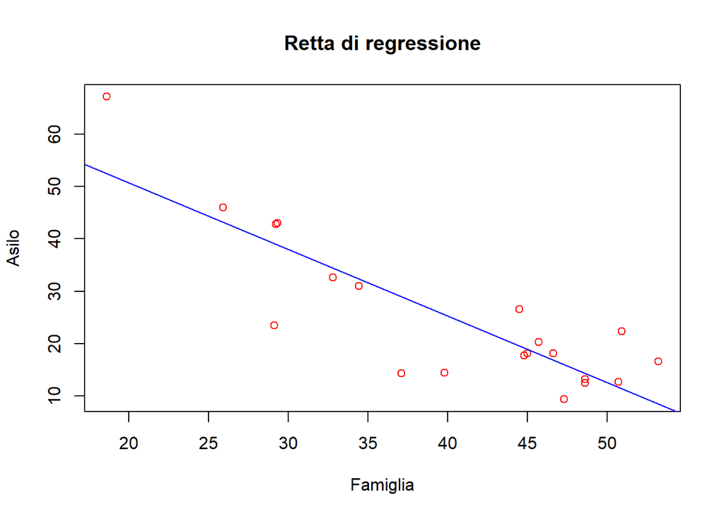

```r
plot(famiglia, asilo, main = "Retta di regressione",
     xlab="Famiglia", ylab="Asilo", col="red")
abline(lm(asilo~famiglia), col="blue")
```

La funzione *abline(lm(asilo~famiglia)* è quella che permette di aggiungere la retta allo scatterplot, dove *lm()* sta per linear model ed è utilizzata per eseguire le analisi di regressioni lineari.

Il modello lineare viene utilizzato per spiegare o prevedere un andamento futuro sulla base della relazione si instaura tra una variabile Y dipendente e una o più variabili indipendenti $X_{1}, X_{2}, ..., X_{p}$. Nel caso in cui $p=1$, l’analisi prende il nome di **regressione semplice** mentre se $p>1$ allora prende il nome di **regressione multipla**.

### Regressione lineare semplice

Questo modello di regressione è esprimibile attraverso l’equazione di una retta che interpola al meglio la nuvola di punti dello scatterplot. L’equazione è la seguente:

$$Y=\alpha+\beta X$$

dove: * $\alpha$ è l’intercetta; * $\beta$ il coefficiente angolare.

Il coefficiente angolare indica la pendenza della retta mentre l’intercetta corrisponde all’ordinata del punto di intersezione della retta interpolante con l’asse delle ordinate. L’identificazione di questa retta viene ottenuta applicando il *metodo dei minimi quadrati*. I **coefficienti di regressione** sono i valori $\alpha$ e $\beta$ per i quali la somma $Q$ dei quadrati degli errori è **minima**:

$$Q = \sum_{i=1}^n [y_{i} - (\alpha+\beta x_i)]^2$$

dove: * $n$ è il numero di osservazioni; * $(x_1, x_2, ..., x_n)$ sono i valori osservati della variabile X; * $(y_1, y_2, ..., y_n)$ sono i valori osservati della variabile Y.

Il metodo dei minimi quadrati conduce alla fine a:

$$\beta = \frac{s_y}{s_x} * r_{xy} \qquad \alpha = \bar{y}-\beta \bar{x}$$

Riferendoci ai vettori da noi presi in considerazione abbiamo che:

```r
beta <- (sd(asilo)/sd(famiglia)) * cor(famiglia,asilo)
alpha <- mean(asilo) - beta*mean(famiglia)

c(alpha,beta)
```

```
## [1] 76.015883 -1.269066
```

Il fatto che $\beta$ risulta essere negativo, ci conferma che la retta è discendente. Per poter eseguire le analisi di regressione lineare utilizziamo la funzione *lm(y~x)* (l’argomento indica che y dipende da x).

```r
linearmodel <- lm(asilo~famiglia)
linearmodel
```

```
##
## Call:
## lm(formula = asilo ~ famiglia)
##
## Coefficients:
## (Intercept)     famiglia
##      76.016       -1.269
```

Vediamo che i coefficienti coincidono con quelli calcolati precedentemente. La retta di regressione con i vettori da noi presi in esame ha come equazione:

$$y = 76.016 - 1.269 * x$$

### Residui

Calcolati i coefficienti di regressione e con essi l’equazione della retta di regressione, è possibile osservare quanto questa retta si discosta dai valori osservati. Esistono quindi degli scostamenti, chiamati **residui**, tra le ordinate dei punti $y_i$ che sono i valori osservati e i corrispondenti valori stimati ottenuti mediante la retta di regressione.

$$\hat{y} = \alpha + \beta x_{i} \qquad (i=1,2,...,n)$$

I residui verranno quindi calcolati nel seguente modo:

$$E_i = y_i - \hat{y_i} \qquad (i=1,2,...,n)$$

È possibile calcolare i valori stimati utilizzando la funzione *fitted()* dandole in input *lm(y~x*)

```r
fitted(lm(asilo~famiglia))
```

```
##         1         2         3         4         5         6         7
## 16.877418  8.501584 19.161736 15.989072 11.420435 14.339286 19.542456
##         8         9        10        11        12        13        14
## 11.674248 25.507065 14.339286 18.907923 28.933543 18.019577 52.411259
##        15        16        17        18        19        20
## 39.086069 38.832256 43.147079 38.959162 34.390525 32.360020
```

Per calcolare i residui invece esiste la funzione *resid()* che prende in input sempre *lm(y~x)*

```r
resid(lm(asilo~famiglia))
```

```
##          1          2          3          4          5          6
##   1.222582   8.098416  -1.461736  -6.589072  10.979565  -1.139286
##          7          8          9         10         11         12
##   7.057544   1.025752 -11.007065  -1.839286  -0.807923 -14.633543
##         13         14         15         16         17         18
##   2.280423  14.688741 -15.586069   4.167744   2.852921   3.840838
##         19         20
##  -1.790525  -1.360020
```

I residui sono anche uno degli attributi fornitoci dalla funzione *lm()* ed è possibile accedervi nella seguente maniera:

```r
linearmodel$residuals
```

```
##          1          2          3          4          5          6
##   1.222582   8.098416  -1.461736  -6.589072  10.979565  -1.139286
##          7          8          9         10         11         12
##   7.057544   1.025752 -11.007065  -1.839286  -0.807923 -14.633543
##         13         14         15         16         17         18
##   2.280423  14.688741 -15.586069   4.167744   2.852921   3.840838
##         19         20
##  -1.790525  -1.360020
```

È inutile calcolare la media campionaria dei residui $\bar{E}$ in quanto essa è sempre nulla perchè gli scostamenti positivi e negativi si compensano a vicenda. Per quanto riguarda invece mediana, varianza campionaria e deviazione standard campionaria:

```r
median(linearmodel$residuals)
```

```
## [1] 0.1089144
```

```r
var(linearmodel$residuals)
```

```
## [1] 59.67764
```

```r
sd(linearmodel$residuals)
```

```
## [1] 7.72513
```

Il coefficiente di variazione è impossibile da ottenere in quanto abbiamo detto che la media campionaria dei residui risulta essere nulla. È possibile visualizzare graficamente i residui attraverso diversi grafici:

- Tracciando dei segmenti che congiungono i valori stimati e i valori osservati utilizzando la funzione *segments()*

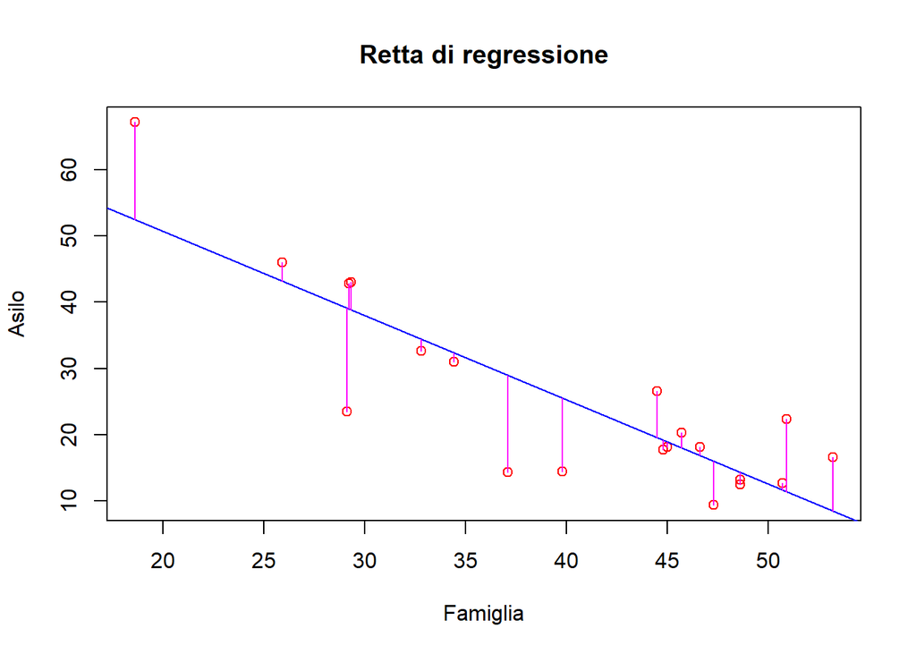

```r
plot(famiglia, asilo, main = "Retta di regressione",
     xlab="Famiglia", ylab="Asilo", col="red")
abline(lm(asilo~famiglia), col="blue")
stime <- fitted(lm(asilo~famiglia))
segments(famiglia, stime, famiglia, asilo, col="magenta")
```

- Rappresentando i valori dei residui rispetto alle osservazioni della variabile indipendente Il **diagramma dei residui** è un grafico in cui i valori dei residui sono posti sull’asse delle ordinate e quelli della variabile indipendente sull’asse delle ascisse.

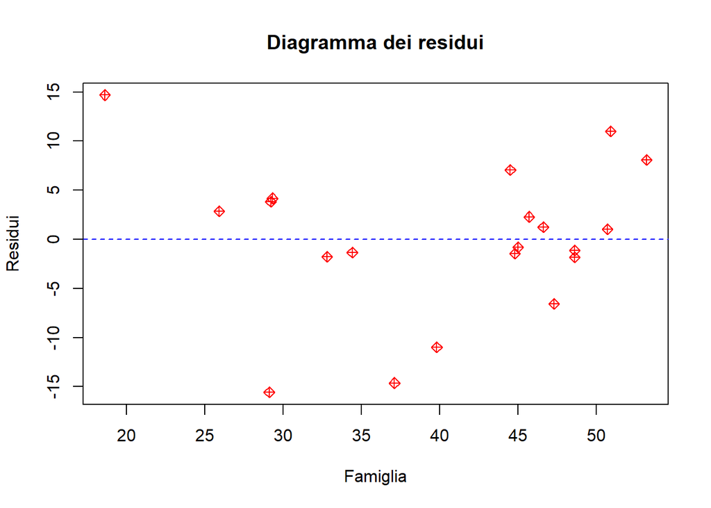

```r
residui <- resid(lm(asilo~famiglia))
plot(famiglia, residui, main = "Diagramma dei residui",
     xlab="Famiglia", ylab="Residui", pch=9, col="red")
abline(h=0, col="blue", lty=2)
```

Questo diagramma ci aiuta a capire come si adatta la retta di regressione rispetto ai dati.

- Calcola i valori dei residui standardizzati rispetto ai valori stimati È possibile calcolare i *residui standardizzati* nella seguente maniera:

$$E_i^{(s)} = \frac{E_i - E}{s_E}$$

che hanno media campionaria nulla e varianza unitaria.

```r
residuistandard <- residui/sd(residui)
residuistandard
```

```
##          1          2          3          4          5          6
##  0.1582604  1.0483210 -0.1892183 -0.8529399  1.4212789 -0.1474779
##          7          8          9         10         11         12
##  0.9135825  0.1327812 -1.4248387 -0.2380913 -0.1045837 -1.8942777
##         13         14         15         16         17         18
##  0.2951954  1.9014230 -2.0175800  0.5395047  0.3693039  0.4971874
##         19         20
## -0.2317793 -0.1760514
```

È possibile rappresentare questi residui standardizzati mediante un grafico:

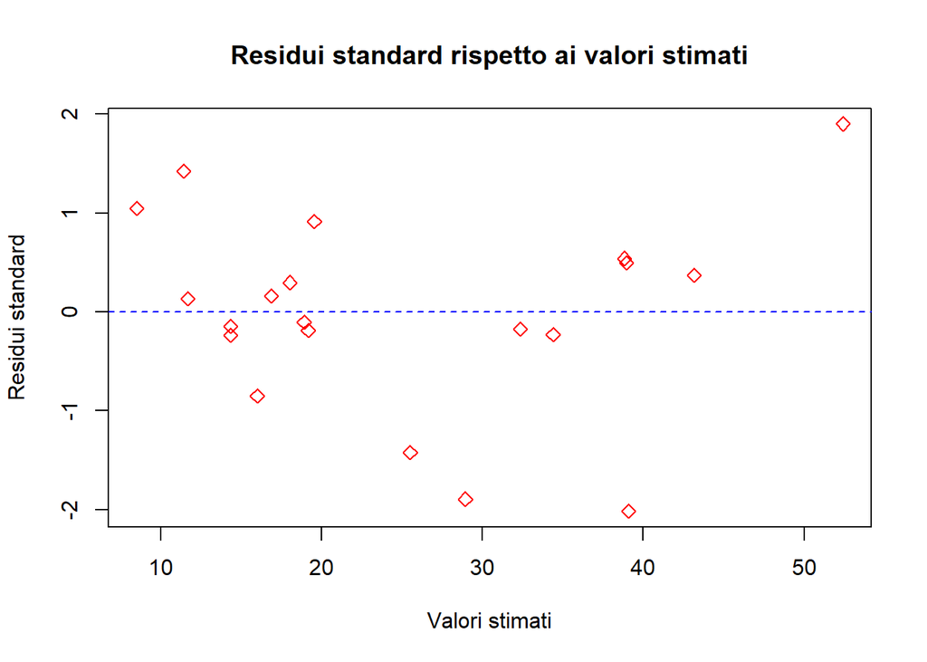

```r
plot(stime, residuistandard,
     main = "Residui standard rispetto ai valori stimati",
     xlab="Valori stimati", ylab="Residui standard",
     pch=5, col="red")
abline(h=0, col="blue", lty=2)
```

### Coefficiente di determinazione

Quello che ci interessa capire è quanto la retta si adatti ai dati e questo lo possiamo fare attraverso il **coefficiente di determinazione** definito nella seguente maniera:

$$D^2 = \frac{\sum_{i=1}^n (\hat{y_i} - \bar{y})²}{\sum_{i=1}^n (y_i - \bar{y})²}$$

Il coefficiente di determinazione è il rapporto tra *la varianza dei valori stimati tramite la retta di regressione* e *la varianza dei valori osservati*.

Nel caso di regressione lineare semplice esso è pari al quadrato del coefficiente di correlazione, ovvero:

$$D^2 = r^2_{xy}$$

Se il coefficiente di determinazione è vicino ad 1 allora fra le due variabili esiste una forte correlazione, se invece questo coefficiente risulta vicino allo 0 non esiste correlazione fra le due variabili. In questo caso, per calcolare il coefficiente di determinazione, possiamo utilizzare il coefficiente di correlazione ed elevarlo al quadrato:

```r
(cor(famiglia, asilo))^2
```

```
## [1] 0.7244754
```

In alternativa possiamo utilizzare la funzione *summary(lm(y~x))$r.square*:

```r
summary(lm(asilo~famiglia))$r.square
```

```
## [1] 0.7244754
```

Com’é possibile vedere, il coefficiente di determinazione fra le due variabili prese in esame risulta essere abbastanza vicino ad 1, indicando una correlazione fra le variabili.

## Regressione lineare multipla

Molte applicazioni affrontano situazioni nelle quali vi è più di una variabile indipendente. Il modello di regressione lineare multipla serve a spiegare la relazione fra una variabile quantitativa dipendente $Y$ e diverse variabili quantitative indipendenti $X_1, X_2, ..., X_p$. Come variabile dipendente scegliamo “Lavoro” e ne valutiamo la relazione con tutte le altre variabili a nostra disposizione. Iniziamo con l’applicare le funzioni *cov()* e *cor()* sul dataframe “motivi” definito in precedenza, nella parte riguardante gli scatterplot, per calcolare la covarianza e le correlazioni fra le coppie di variabili. Gli output delle funzioni saranno due matrici simmetriche.

```r
cov(motivi)
```

```
##              lavoro    famiglia     studio       asilo     altro
## lavoro    52.484711   27.536026   3.174447  -84.309053  1.294682
## famiglia  27.536026   97.433132   7.321026 -123.649053 -8.615503
## studio     3.174447    7.321026   1.701553  -12.275895  0.076550
## asilo    -84.309053 -123.649053 -12.275895  216.596421  3.453884
## altro      1.294682   -8.615503   0.076550    3.453884  3.773721
```

```r
cor(motivi)
```

```
##               lavoro   famiglia      studio      asilo       altro
## lavoro    1.00000000  0.3850628  0.33591472 -0.7907372  0.09199446
## famiglia  0.38506277  1.0000000  0.56858571 -0.8511612 -0.44930619
## studio    0.33591472  0.5685857  1.00000000 -0.6394474  0.03020909
## asilo    -0.79073720 -0.8511612 -0.63944740  1.0000000  0.12080843
## altro     0.09199446 -0.4493062  0.03020909  0.1208084  1.00000000
```

Il modello di regressione lineare multipla con p variabili è esprimibile attraverso l’equazione:

$$Y = \alpha + \beta_1 X_1 + \beta_2 X_2 +...+\beta_p X_p$$

dove: * $\alpha$ rappresenta l’intercetta, ovvero il valore di Y quando $X_1=X_2=...=X_p=0$ * $\beta_1 , \beta_2, ..., \beta_p$ sono i regressori. Abbiamo che $\beta_1$ rappresenta l’inclinazione di $Y$ rispetto alla variabile $X_1$ tenendo costanti le variabili $X_2, X_3, ..., X_p$ , $\beta_2$ rappresenta l’inclinazione… e così fino a $\beta_p$.

Utilizziamo la funzione *lm(y~$x_1+x_2+...+x_p$)* per eseguire l’analisi di regressioni lineari multivariate:

```r
multiplelinearmodel <- lm(lavoro ~ famiglia + studio + asilo + altro)
multiplelinearmodel$coefficients
```

```
## (Intercept)    famiglia      studio       asilo       altro
##  100.462590   -1.006580   -1.006555   -1.004737   -1.014970
```

I segni di tutti i regressori sono negativi, questo vuol dire che i valori di “Famiglia”, “Studio”, “Asilo”" e “Altro” hanno un effetto negativo sul valore di “Lavoro”, in altre parole al crescere dei valori “Famiglia”, “Studio”, “Asilo”" e “Altro” diminuisce quello di “Lavoro”.

###Residui

Calcolati i coefficienti passiamo al calcolo dei residui. Prima di calcolare i residui bisogna calcolare i valori stimati che risultano essere uguali a:

$$\hat{y_i} = \alpha + \beta_1 x_{i,1} + \beta_2 x_{i,2} +...+\beta_p x_{i,p} \qquad (i=1,2,...,n)$$
Ricordiamo che la media campionaria dei residui $\bar{E}$ è sempre nulla. I residui li calcoliamo esattamente come prima:

$$E_i = y_i - \hat{y_i}$$
Utilizziamo anche qui la funzione *fitted()* per calcolare i valori stimati tramite regressione lineare multipla:

```r
stimemult <- fitted(lm(lavoro ~ famiglia + studio + asilo + altro))
stimemult
```

```
##        1        2        3        4        5        6        7        8
## 28.34642 26.08850 30.84782 38.69300 22.17606 35.20738 23.50679 31.37730
##        9       10       11       12       13       14       15       16
## 39.33268 30.51090 31.36360 34.08336 27.99525 10.82657 41.65093 21.68974
##       17       18       19       20
## 21.52531 23.66772 28.02987 28.18080
```

```r
residuimult <- resid(lm(lavoro ~ famiglia + studio + asilo + altro))
residuimult
```

```
##            1            2            3            4            5
## -0.046415472  0.011495272  0.052183935  0.106999953 -0.076064888
##            6            7            8            9           10
## -0.007381926 -0.006789891  0.022696499 -0.032684485 -0.010901486
##           11           12           13           14           15
##  0.036403466  0.016637996  0.004750038  0.073425725 -0.050925030
##           16           17           18           19           20
## -0.089736047  0.074694203 -0.067724913 -0.029867500  0.019204553
```

Per quanto riguarda mediana, varianza campionaria e deviazione standard dei residui abbiamo che:

```r
median(multiplelinearmodel$residuals)
```

```
## [1] -0.001019927
```

```r
var(multiplelinearmodel$residuals)
```

```
## [1] 0.002796633
```

```r
sd(multiplelinearmodel$residuals)
```

```
## [1] 0.0528832
```

Anche nel caso multivariato è interessante calcolare i residui standardizzati e lo facciamo attraverso le seguenti linee di codice:

```r
residuimultstandard <- residuimult/sd(residuimult)
residuimultstandard
```

```
##           1           2           3           4           5           6
## -0.87769787  0.21737095  0.98677718  2.02332599 -1.43835638 -0.13958925
##           7           8           9          10          11          12
## -0.12839411  0.42918164 -0.61805043 -0.20614271  0.68837487  0.31461780
##          13          14          15          16          17          18
##  0.08982131  1.38845087 -0.96297179 -1.69687249  1.41243726 -1.28065081
##          19          20
## -0.56478238  0.36315035
```

Realizziamo quindi un grafico in cui i residui standardizzati vengono disegnati in funzione dei valori stimati

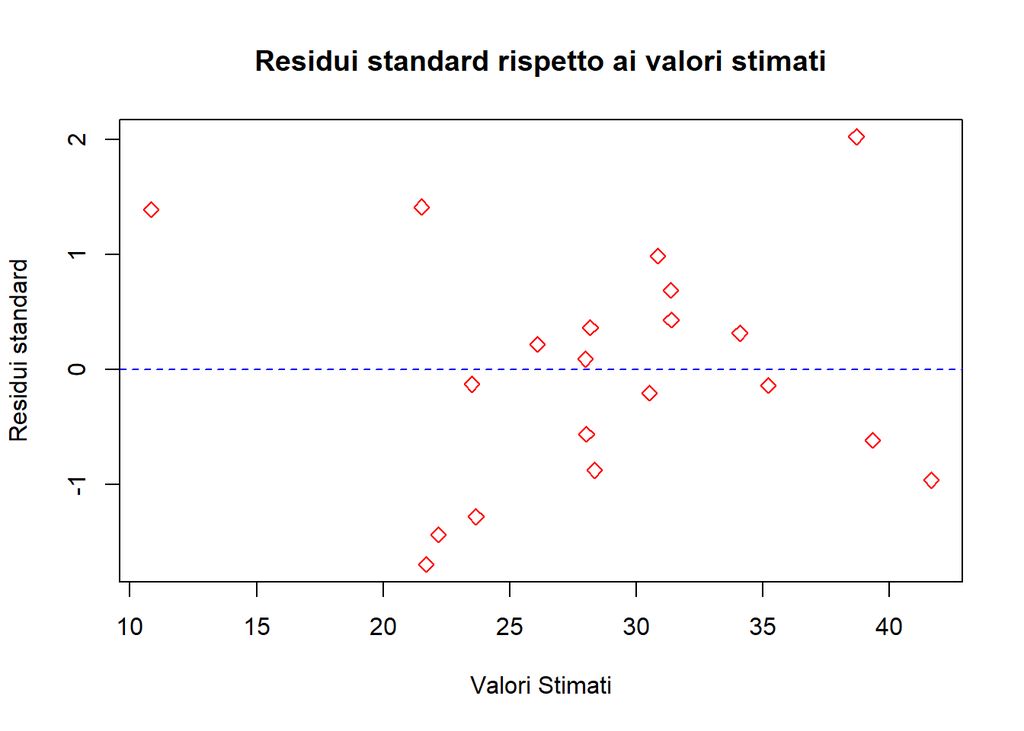

```r
plot(stimemult,residuimultstandard,
     main="Residui standard rispetto ai valori stimati",
     ylab="Residui standard", xlab="Valori Stimati",
     pch=5, col="red")
abline(h=0, col="blue", lty=2)
```

I punti risultano essere disposti anche in questo caso in maniera del tutto casuale e non è possibile notare nessuna tendenza.

### Coefficiente di determinazione

Come in precedenza, il coefficiente di determinazione è uguale a:

$$D^2 = \frac{\sum_{i=1}^n (\hat{y_i} - \bar{y})²}{\sum_{i=1}^n (y_i - \bar{y})²}$$

Ed esattamente come prima, se $D^2 = 0$ allora il modello di regressione multipla usato non spiega per nulla i dati, se $D^2 = 1$ allora il modello approssima perfettamente i dati.

Utilizziamo la funzione *summary(lm(y~$x_1+x_2+...+x_p$))$r.square* per calcolarlo. Utilizzando i dati a nostra disposizione otteniamo:

```r
summary(lm(lavoro ~ famiglia+studio+asilo+altro))$r.square
```

```
## [1] 0.9999467
```

Essendo il valore del coefficiente decisamente vicino ad 1, il modello di regressione multipla utilizzato spiega in maniera ottima i dati.

## Regressione non lineare

Molto spesso la linearità non è un modello accettabile e lo notiamo quando il coefficiente di determinazione è prossimo allo 0. Il modello lineare più semplice è il **modello di regressione polinomiale** che calcoliamo nella seguente maniera:

$$Y = \alpha + \beta X + \gamma X^2$$

Degli scatterplot creati in precedenza, in gran parte sembra che la linearità non basti. Esaminiamo nel dettagli la coppia “Lavoro” e “Asilo”

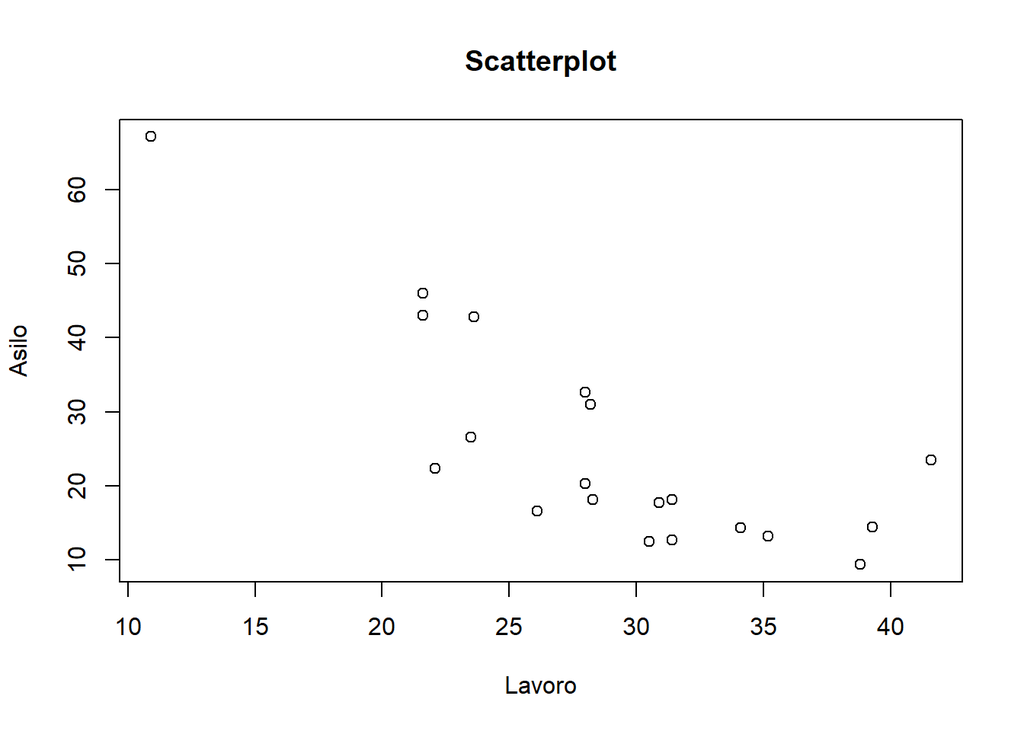

```r
plot(lavoro, asilo, main="Scatterplot", xlab="Lavoro", ylab="Asilo")
```

Calcolando il coefficiente di determinazione esso risulta pari a:

```r
summary(lm(asilo ~ lavoro))$r.square
```

```
## [1] 0.6252653
```

Un valore che si trova nel mezzo ma che, utilizzando un modello di regressione non lineare possiamo far aumentare e approssimare meglio.

Per la stima dei parametri $\alpha, \beta e \gamma$ è possibile ricorrere alla regressione multipla:

$$Y = \alpha + \beta X_1 + \gamma X_2$$

con regressori $X_1 = X$ e $X_2 = X^2$.

Utilizzando R possiamo stimare $\alpha, \beta$ e $\gamma$ con la funzione *lm(y~x + I(x^2))* dove *I()* è un *identificatore di variabile* e viene inserito quando vi è la necessità di effettuare operazione matematiche nelle variabili della regressione, in questo caso, l’elevazione a potenza.

Procediamo all’approssimazione polinomiale

```r
pol <- lm(asilo~lavoro+I(lavoro^2))
pol
```

```
##
## Call:
## lm(formula = asilo ~ lavoro + I(lavoro^2))
##
## Coefficients:
## (Intercept)       lavoro  I(lavoro^2)
##   124.38170     -5.72361      0.07451
```

```r
alphapol <- pol$coefficients[[1]]
betapol <- pol$coefficients[[2]]
gammapol <- pol$coefficients[[3]]

c(alphapol, betapol, gammapol)
```

```
## [1] 124.38169775  -5.72360516   0.07450643
```

Il modello polinomiale costruito ha quindi come valori $\alpha = 124.3816$, $\beta = -5.7236$ e come $\gamma = 0.0745$. Procediamo col calcolo del coefficiente di determinazione attraverso la funzione *summary()*:

```r
summary(lm(asilo~lavoro+I(lavoro^2)))$r.square
```

```
## [1] 0.7709843
```

Com’è possibile notare, il coefficiente di determinazione ottenuto col modello di regressione non lineare polinomia dal valore di 0.7709 è maggiore di quello di regressione lineare dal valore di 0.6252, risultando quindi più ottimale.

Andiamo adesso ad aggiungere la curva appena descritta allo scatterplot:

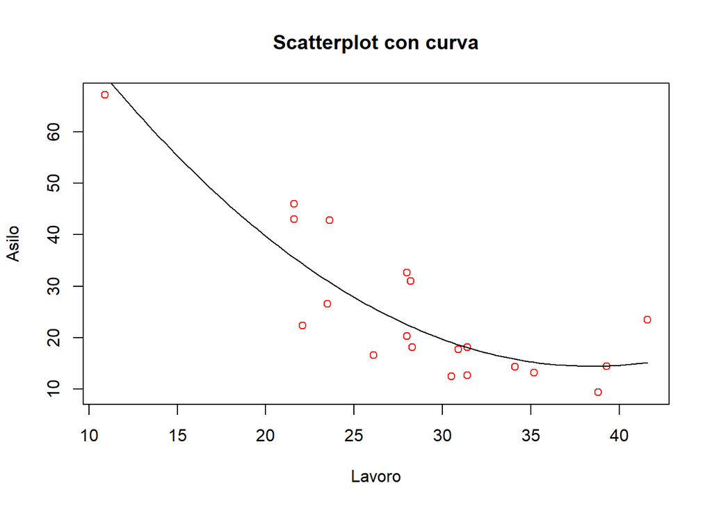

```r
plot(lavoro, asilo, main="Scatterplot con curva",
     xlab="Lavoro", ylab="Asilo", col = "red")
curve(alphapol+betapol*x+gammapol*x^2, add = TRUE)
```

# Analisi dei cluster

L’analisi dei cluster è una metodologia che permette di raggruppare in sottoinsiemi entità appartenenti ad un insieme più ampio. Questi sottoinsiemi sono chiamati **cluster**. Le diverse tecniche per effettuare l’analisi dei cluster hanno come unico obiettivo quello di ottenere raggruppamenti in base alla somiglianza in modo che gli elementi di uno stesso gruppo siano tra loro più simili possibili e gli elementi appartenenti a gruppi diversi siano più diversi possibili. Sia $n$ il numero di individui, il problema dell’analisi dei cluster sta nel determinare $m$ sottoinsiemi, i cluster, di individui in $I$, con $m$ minore intero di $n$, tali che $I_i$ appartenga soltanto ad un unico sottoinsieme. Gli individui assegnati allo stesso cluster sono detti **simili**, mentre quelli assegnati a cluster diversi vengono chiamati **dissimili**. Molte delle tecniche di analisi dei cluster prevedono la standardizzazione di ogni variabile usanto dal media campionaria e la deviazione standard campionaria, questo per far si che tutti i valori osservati siano privi di unità di misura. Questa operazione è detta *scalamento* e, oltre a rendere puri i valori osservati, ci permette di ridurne la grandezza. Preso un elemento $x_{ij}$, il corrispondente valore scalato è pari a:

$$\frac{x_{ij} - \bar{x}}{s_j}$$
Nel nostro caso, i valori risultano essere in percentuali, quindi non vi è bisogno di effettuare scalamento, di seguito mostreremo solo gli effetti dello scalamento sulla nostra tabella.

R fornisce la funzione *scale()* che, data una matrice in input, permette di effettuare uno scalamento. Questa funzione prevede due attributi, *center* che di default è uguale a TRUE e indica se dagli elementi di ogni colonna della matrice si sottrae il valore medio della corrispondente colonna e *scale*, che di default è posto anch’esso a TRUE e indica se bisogna dividere gli elementi centrati di ogni colonna della matrice per la deviazione standard della rispettiva colonna.

Mostriamo i la nostra tabella:

```r
tabellaScalata <- scale(tabella)
tabellaScalata
```

```
##                  lavoro    famiglia      studio      asilo       altro
## Piemonte    -0.06280511  0.65799990  1.75938140 -0.4769924 -0.70292149
## Valle d'Aos -0.36647818  1.32663720 -0.46380207 -0.5789139 -0.68233060
## Liguria      0.29608124  0.47564427  0.22615142 -0.5041715  0.17219131
## Lombardia    1.38654362  0.72891597  0.45613592 -1.0681369 -1.00663711
## T-A Adige   -0.91861103  1.09362723  0.07282842 -0.1848176 -0.83676227
## Veneto       0.88962406  0.86061726 -0.77044806 -0.8099358 -1.02208028
## F-V Giulia  -0.72536453  0.44525166  0.22615142  0.1005625 -0.48671715
## Em-Romag     0.36509785  1.07336550  0.53279742 -0.8439097 -0.76469416
## Toscana      1.45556023 -0.03089915  0.53279742 -0.7216039 -0.15211520
## Umbria       0.24086796  0.86061726  1.98936590 -0.8574992 -0.12122886
## Marche       0.36509785  0.49590600  0.45613592 -0.4769924 -0.54848982
## Lazio        0.73778752 -0.30443259  1.68271990 -0.7351934  3.22479069
## Abruzzo     -0.10421508  0.56682208 -0.15715607 -0.3275076  0.08982776
## Molise      -2.46458302 -2.17864323 -1.38374006  2.8524418 -0.39920587
## Campania     1.77303662 -1.11490206 -1.15375556 -0.1100752  0.67152039
## Puglia      -0.98762764 -1.09464032 -0.69378657  1.2149038  0.45016832
## Basilicata  -0.98762764 -1.43908984 -1.07709406  1.4187467  0.99582690
## Calabria    -0.71156121 -1.10477119 -0.54046357  1.2013142 -0.50216032
## Sicilia     -0.10421508 -0.74005993 -1.38374006  0.5082483  1.20688351
## Sardegna    -0.07660843 -0.57796604 -0.31047907  0.3995321  0.41413427
## attr(,"scaled:center")
##   lavoro famiglia   studio    asilo    altro
##  28.7550  40.1050   2.5050  25.1200   3.5255
## attr(,"scaled:scale")
##    lavoro  famiglia    studio     asilo     altro
##  7.244633  9.870822  1.304436 14.717215  1.942607
```

##Distanza e similarità

Le misure metriche di somiglianza sono basate soprattutto sulle *funzioni distanza* tra i vettori delle caratteristiche. La definizione di questa funzione è la seguente:

1. $d(X_i, X_j) = 0$ se e solo se $ X_i = X_j$, con $X_i$ e $X_j$ in $E_p$;
2. $d(X_i, X_j) \geq 0$ per ogni $X_i$ e $X_j$ in $E_p$;
3. $d(X_i, X_j) = d(X_j, X_i) $ per ogni $X_i$ e $X_j$ in $E_p$;
4. $d(X_i, X_j) \leq d(X_i, X_k) + d(X_k, X_j)$ per ogni $X_i$ ,$X_j$ e $X_k$ in $E_p$.

Queste proprietà rappresentano le caratteristiche che deve possedere una funzione di distanza. Le distanze calcolate fra tutte le possibili coppie vengono inserite in una matrice simmetrica di cardinalità $n x n$, con ovviamente tutti 0 sulla diagonale, ed è quindi possibile considerare anche solo la matrice triangolare superiore. R ha a disposizione la funzione *dist(X, method=, diag=FALSE, upper=FALSE)* per calcolare la matrice delle distanze secondo un metodo impostato dall’utente attraverso l’attributo *method*.

I possibili valori di method, rappresentano i metodi disponibili per il calcolo della matrice delle distanze e, in particolare abbiamo:

1. metrica euclidea (**euclidean**)
2. metrica del valore assoluto o metrica di Manhattan (**manhattan**)
3. metrica del massimo o metrica di Chebycev (**maximum**)
4. metrica di Minkowski (**minkowski**)
5. distanza di Canberra (**canberra**)
6. distanza di Jaccard (**binary**)

### Metrica euclidea

La metrica più diffusa e familiare e quella **euclidea**, definita come segue:

$$d_{2}(X_i,X_j) = \sum_{k=1}^p [(x_{ik} - x_{jk})^2]^\frac{1}{2}$$

La metrica euclidea usata su tutti i dati, è fortemente influenzata dall’unità di misura base alla quale è valutata ciascuna delle p caratteristiche. Per usare questa metrica in R basta settare *“euclidean”* come valore dell’attributo *method* della funzione *dist()*.

Per i dati a nostra disposizione abbiamo che:

```r
dist(tabella, method="euclidean", diag=FALSE, upper=FALSE)
```

```
##              Piemonte Valle d'Aos   Liguria Lombardia T-A Adige    Veneto
## Valle d'Aos  7.685155
## Liguria      4.129165    9.918447
## Lombardia   13.772004   15.804332 11.953414
## T-A Adige    8.962567    7.450503 11.858398 21.475775
## Veneto       9.321717   10.776159  7.762242  5.625913 16.213562
## F-V Giulia  10.191977   13.542688 11.648966 23.213791  7.814243 18.331165
## Em-Romag     7.625903    7.160000  7.970721  8.800051 13.453609  4.715930
## Toscana     13.561154   18.998971 10.312948  9.234479 21.990655 10.083953
## Umbria       6.447240    8.292050  6.874220  9.335331 13.492298  6.213091
## Marche       3.892300    9.954275  1.581139 11.684695 11.847092  7.403810
## Lazio       14.019875   19.848126 10.948283 14.841442 21.603521 14.593577
## Abruzzo      3.789670    8.715503  4.031823 15.594451  8.342062 10.768733
## Molise      59.202349   63.088767 59.434351 70.274764 56.312987 66.315942
## Campania    23.105603   29.604001 19.970000 23.514413 29.459207 23.202890
## Puglia      31.296128   35.963176 31.121722 41.941136 29.973655 38.127150
## Basilicata  35.726321   40.511327 35.355905 45.961855 34.599618 42.327490
## Calabria    30.726082   35.620535 30.485670 40.949486 29.838943 37.258423
## Sicilia     20.769066   26.280771 19.567067 29.822475 22.041572 26.405092
## Sardegna    18.090299   23.870209 17.118730 27.458106 19.737652 23.992167
##             F-V Giulia  Em-Romag   Toscana    Umbria    Marche     Lazio
## Valle d'Aos
## Liguria
## Lombardia
## T-A Adige
## Veneto
## F-V Giulia
## Em-Romag     17.161340
## Toscana      20.462710 13.633639
## Umbria       16.444273  3.229938 12.747298
## Marche       11.619570  7.863612 10.149527  7.058250
## Lazio        19.339186 16.035040  8.924887 13.815209 11.850270
## Abruzzo       7.929968  9.893715 14.041756  9.138277  4.366646 13.784705
## Molise       49.741923 66.458815 63.476298 65.459694 59.363744 61.105577
## Campania     24.138817 26.454945 14.428444 25.370093 19.900676 15.594281
## Puglia       22.546893 38.473622 35.209642 37.355483 31.121594 32.854864
## Basilicata   27.149851 42.849462 38.834687 41.682837 35.387286 36.308248
## Calabria     22.305625 37.832791 34.090503 36.789912 30.368867 32.337866
## Sicilia      14.435169 27.366017 22.749057 26.190006 19.698683 20.541577
## Sardegna     12.124871 24.845002 20.664946 23.648712 17.132043 18.909299
```

[output cut: 25 more lines]

```
## Veneto
## F-V Giulia
## Em-Romag
## Toscana
## Umbria
## Marche
## Lazio
## Abruzzo
## Molise
## Campania
## Puglia
## Basilicata
## Calabria
## Sicilia
## Sardegna     3.080844
```

###Metrica di Manhattan

La metrica di Manhattan è così definita:

$$d_1(X_i, X_j) = \sum_{k=1}^p |x_{ik} - x_{jk}|$$

Calcoleremo queste altre metriche utilizzate solo su una parte delle regioni, giusto per mostrare la differenza nei risultati.

Per utilizzare questa metrica, bisogna dare *“manhattan”* come valore all’attributo *method* della funzione *dist()*.

```r
x <- tabella[1:5, 1:5]
x
```

```
##             lavoro famiglia studio asilo altro
## Piemonte      28.3     46.6    4.8  18.1  2.16
## Valle d'Aos   26.1     53.2    1.9  16.6  2.20
## Liguria       30.9     44.8    2.8  17.7  3.86
## Lombardia     38.8     47.3    3.1   9.4  1.57
## T-A Adige     22.1     50.9    2.6  22.4  1.90
```

```r
dist(x, method = "manhattan", diag = FALSE, upper=FALSE)
```

```
##             Piemonte Valle d'Aos Liguria Lombardia
## Valle d'Aos    13.24
## Liguria         8.50       16.86
## Lombardia      22.19       27.63   21.29
## T-A Adige      17.26       13.10   21.76     34.13
```

###Metrica di Chebycev o del massimo

La metrica di Chebycev è definita nella seguente maniera:

$$d_\infty (X_i, X_j) = max_{k=1,...,p}|X_{ik} - X_{jk}|$$

Per utilizzare questa metrica, bisogna dare *“maximum”* come valore all’attributo *method* della funzione *dist()*.

```r
dist(x, method = "maximum", diag = FALSE, upper=FALSE)
```

```
##             Piemonte Valle d'Aos Liguria Lombardia
## Valle d'Aos      6.6
## Liguria          2.6         8.4
## Lombardia       10.5        12.7     8.3
## T-A Adige        6.2         5.8     8.8      16.7
```

###Metrica di Minkowski

La metrica di Minkowsi è definita come segue:

$$d_r(X_i, X_j) = [\sum_{k=1}^p|x_{ik}-x_{jk}|^r]^\frac{1}{r}$$

con $r \geq 1$. Se $r=2$ si ottiene la metrica euclidea, se invece $r=1$ allora si ottiene la metrica del valore assoluto mentre se $r=\infty$ si ottiene la metrica di Chebycev. Per utilizzare questa metrica, bisogna dare *“minkowski”* come valore all’attributo *method* della funzione *dist()* e bisogna fornire il parametro r. Nell’esempio seguente abbiamo posto $r=4$

```r
dist(x, method = "minkowski", 4, diag = FALSE, upper=FALSE)
```

```
##              Piemonte Valle d'Aos   Liguria Lombardia
## Valle d'Aos  6.684634
## Liguria      2.996038    8.619268
## Lombardia   11.565630   13.151498  9.659892
## T-A Adige    6.836819    6.134183  9.423024 18.065344
```

### Metrica di Canberra

La metrica di Canberra è definita come segue:

$$d_c(X_i,X_j) = \sum_{k=1}^p\frac{|x_{ik} - x_{jk}|}{|x_{ik}+x_{jk}|}$$
Per utilizzare questa metrica, bisogna dare *“canberra”* come valore all’attributo *method* della funzione *dist()*.

```r
dist(x, method = "canberra", diag = FALSE, upper=FALSE)
```

```
##              Piemonte Valle d'Aos   Liguria Lombardia
## Valle d'Aos 0.5918112
## Liguria     0.6203357   0.6674115
## Lombardia   0.8536681   0.9384240 0.9193390
## T-A Adige   0.6346280   0.4825259 0.7243004 0.9025051
```

### Metrica di Jaccard

In R è disponibile la distanza di Jaccard solo per vettori binari, diversi da quelli a nostra disposizione. Non è quindi possibile calcolarla.

## Misure di similarità

In alternativa alla matrice delle distanze, è possibile utilizzare una matrice delle similarità. Una **misura di similarità** fornisce un valore numerico compreso tra 0 e 1 e permette di definire quantitativamente la somiglianza o differenza fra due individui. In generale, una funzione a valori reali $s_{ij} = s(X_i, X_j)$ è detta misura di similarità se e soltanto se essa sosddisfa le seguenti condizioni:

1. $s(X_i,X_i) = 1$;
2. $0\leq s(X_i,X_j) \leq 1$;
3. $s(X_i,X_j) = s(X_j,X_i)$ per ogni $X_i$ e $X_j$

La quantità $s_{ij}$ è detta **coefficiente di similarità**. La principale differenza fra una misura di distanza e una di similarità è che la prima è sempre maggiore o uguale di 0 mentre la seconda risulta essere compresa fra -1 e 1. È sempre possibile trasformare una misura di distanza in una misura di similarità nella seguente maniera:

$$s_{ij} = \frac{1}{1+d_{ij}} \qquad (i,j = 1, 2,..., n)$$

## Misura di non omogeneità totale

Consideriamo un insieme di n individui e supponiamo esista un insieme di p caratteristiche osservabili e possedute da ogni individuo. Alla matrice delle misure è possibile associare una matrice $W_x$ di cardinalità $p*p$ detta **matrice delle varianze e covarianze** dove il generico elemento $w_{rl}$ è definito nella seguente maniera:

$$w_{rl} = \frac{1}{n-1}\sum_{i=1}^n (x_{ir} - \bar{x_{r}})(x_{il} - \bar{x_{l}}) \qquad (r,l= 1,2,...,p)$$

Se $r=l$ allora l’elemento $w_{rl}$ sarà uguale alla varianza campionaria relativa alla caratteristica r-esima effettuata su tutti gli n individui, mentre se $r \neq l$ l’elemento $w_{rl}$ è uguale alla covarianza campionaria tra la caratteristica r-esima e la caratteristica l-esima effettuata su tutti gli n individui.

Dalla matrice delle varianze e covarianze è possibile ricavare una matrice chiamata **matrice statistica di non omogeneità**, indicata con $H_I$, per l’insieme I di individui di cardinalità $p*p$ dove il generico elemento è definito nella seguente maniera:

$$h_{rl} = \sum_{i=1}^{n} (x_{ir} - \bar{x_r}) (x_{il} - \bar{x_l}) = (n-1)w_{rl} \qquad (r,l = 1,2,...,p)$$

In questa matrice, quando $r=l$ l’elemento $h_{rr}$ corrisponde a n-1 volte la varianza campionaria della caratteristica r-esima su tutti gli individui. Una **misura di non omogeneità statistica** dell’insieme I di individui corrisponde alla **traccia** delle matrice $H_I$ ed è definita come segue:

$$trH_I = \sum_{r=1}^{p}h_{rr} = (n-1)\sum_{r=1}^{p}s_r^2$$
oppure in alternativa:

$$trH_I = \sum_{i=1}^{n}d_2^2(X_i, \bar{X})$$

dove $d_2$ indica la distanza euclidea e $\bar{X} = (\bar{x_1}, \bar{x_2}, ..., \bar{x_p})$ è un vettore dove il generico elemento $\bar{x_j}$ rappresenta la media campionaria della caratteristca j-esima sugli n individui.

## Misure di non omogeneità tra cluster

Oltre a misure di non omogeneità relative all’insieme totale, vanno definite anche misure di non omogeneità all’interno dei cluster e tra cluster distinti. Infatti, al termine della classificazione, gli individui che appartengono allo stesso cluster dovrebbero essere il più omogenei tra loro e il più differenti da quelli appartenenti a cluster diversi.

È quindi possibile definire una **misura di non omogeneità totale** che tenga conto della non omogeneità interna ai cluster (*within*) e della non omogeneità fra cluster (*between*). Denotiamo questa misura di non omogeneità totale con T e la definiamo come:

$$T = S + B$$

dove *S* corrisponde alla somma delle matrici di non omogeneità statistica relative ai singoli cluster ed *B* la matrice di non omogeneità statistica tra i vari cluster considerati. Le matrici T, S e B risultano avere tutte e tre la stessa cardinalità. Per ogni fissata matrice di dati, anche la matrice T è fissata mentre invece, le matrici S e B dipendono strettamente dalla partizione in cluster considerata. Per ogni partizione dell’insieme degli individui in un numero fissato di cluster, otteniamo che:

$$trT = trS + trB$$

o, in maniera equivalente:

$$1 = \frac{trS}{trT} + \frac{trB}{trT}$$
e siccome abbiamo detto che *trT* è fissata allora i cluster dovrebbero essere individuati in modo da **minimizzare*** la misura di non omogeneità statistica all’interno dei cluster* e **massimizzare** *la misura di non omogeneità statistica fra cluster*.

## Metodi di ottimizzazione

Scelta la misura di distanza (o la similarità in alternativa) bisogna scegliere un algoritmo di raggruppamento delle unità osservate. I metodi di raggruppamento si suddividono in tre tipi:

- **Metodo di enumerazione completa**;
- **Metodi gerarchici**;
- **Metodi non gerarchici**.

Il primo metodo elencato, quello di enumerazione completa (di ottimizzazione), è computazionalmente oneroso da applicare in quanto bisogna calcolare la funzione obiettivo per ogni partizione dell’insieme totale e questo va bene solo quando abbiamo un insieme di dati piccolo. Vengono per questo adottati metodi di raggruppamento gerarchici e non gerarchici che operano su sottoclassi delle partizioni degli individui in cluster.

### Metodi non gerarchici

Si è scelto di effettuare prima la suddivisione in cluster utilizzando dei metodi non gerarchici in modo da stabilire il numero di partizioni ottimale, sfruttandolo successivamente nell’analisi mediante metodi gerarchici. I metodi non gerarchici consentono di riallocare gli individui già classificati precedentemente nell’analisi e l’obiettivo finale di queste tecniche è quello di ottenere un’unica partizione degli individui di partenza. Per quanto riguarda il numero di cluster da individuare, in molti metodi non gerarchici si assume che esso sia fissato da chi sta facendo l’analisi mentre in altri questo numero è determinato durante l’analisi stessa. Il metodo non gerarchico più utilizzato è quello del **k-means** (Hartigan e Wong, 1979) nel quale il numero di cluster è specificato a priori e fornisce in output un’unica partizione. I passi dell’algoritmo sono i seguenti:

1.Fissare il numero *m* dei cluster specificando *m* punti iniziali (scegliendo alcuni individui o prendendo una configurazione determinata con una tecnica gerarchica) che inducono una prima partizione provvisoria;

2. Considerare tutti gli individui e attribuire ciascuno di essi al cluster individuato dal punto di riferimento da cui ha distanza minore;
3. Calcolare il baricentro (centroide) di ognuno degli m gruppi così ottenuti. Tali centroidi costituiscono i punti di riferimento per i nuovi cluster;
4. Valutare ogni distanza di ogni unità dal centroide ottenuto al punto precedente;
5. Ricalcolare i centroidi dei k gruppi così ottenuti;
6. Ripeto il procedimento dal punto 4 fino ad ottenere una partzione che risulta essere stabile oppure dopo aver raggiunto un determinato numero di iterazioni.

Per garantire la convergenza della procedura iterativa, viene utilizzata la distanza euclidea come misura di distanza fra i vettori delle caratteristiche e i centroidi e viene considerata *la matrice contenente i quadrati delle distanze euclidee*. Il metodo k-means risulta essere molto veloce nei calcoli e lascia estrema libertà agli individui di allontanarsi o raggrupparsi. Uno svantaggio riguarda il fatto che la classificazione finale può essere influenzata dalla scelta iniziale degli m vettori delle caratteristiche come punti di riferimento. Infatti vi è il rischio di cadere in un ottimo locale e non in uno globale.

Per utilizzare il metodo k-means in R bisogna utilizzare la funzione *kmeans(X, centers, iter.max=N, nstart=M)*. Per la nostra analisi utilizzeremo un valore di centers pari a 4, un numero di iterazioni pari a 25 e un valore di nstart uguale a 10.

```r
km <- kmeans(tabella, centers = 4, iter.max = 25, nstart = 10)
km
```

```
## K-means clustering with 4 clusters of sizes 11, 1, 3, 5
##
## Cluster means:
##     lavoro famiglia   studio    asilo    altro
## 1 29.65455 47.80909 3.018182 17.05455 2.481818
## 2 10.90000 18.60000 0.700000 67.10000 2.750000
## 3 38.33333 35.33333 2.966667 17.43333 5.950000
## 4 24.60000 30.32000 1.460000 39.08000 4.522000
##
## Clustering vector:
##    Piemonte Valle d'Aos     Liguria   Lombardia   T-A Adige      Veneto
##           1           1           1           1           1           1
##  F-V Giulia    Em-Romag     Toscana      Umbria      Marche       Lazio
##           1           1           3           1           1           3
##     Abruzzo      Molise    Campania      Puglia  Basilicata    Calabria
##           1           2           3           4           4           4
##     Sicilia    Sardegna
##           4           4
##
## Within cluster sum of squares by cluster:
## [1] 581.7618   0.0000 177.0051 280.4055
##  (between_SS / total_SS =  85.3 %)
##
## Available components:
##
## [1] "cluster"      "centers"      "totss"        "withinss"
## [5] "tot.withinss" "betweenss"    "size"         "iter"
## [9] "ifault"
```

```r
km$totss
```

```
## [1] 7067.801
```

```r
km$tot.withinss
```

```
## [1] 1039.172
```

```r
km$betweenss
```

```
## [1] 6028.629
```

```r
km$betweenss/km$totss
```

```
## [1] 0.8529709
```

Possiamo notare che la misura di non omogeneità totale è pari a 7067.801, mentre la somma delle misure di non omogeneità totale interne è uguale a 1039.17, la misura di non omogeneità tra cluster diversi è 6028.62 e il rapporto fra $\frac{trB}{trT}$ risulta essere pari a 0.853, un valore decisamente ottimo considerando il numero di centri utilizzato.

Nell’analisi che effettueremo con i metodi gerarchici utilizzeremo lo stesso numero di cluster.

È possibile anche scegliere i centroidi come punti di riferimento:

```r
d<-dist(tabella, method="euclidean", diag = TRUE, upper = TRUE)
d2 <- d^2
tree <- hclust(d2, method = "centroid")
taglio <- cutree(tree, k = 4, h = NULL)
tagliolist <- list(taglio)
centroidiIniziali <- aggregate(tabella, tagliolist, mean)[,-1]
kmeans(tabella, centers = centroidiIniziali, iter.max = 25)
```

```
## K-means clustering with 4 clusters of sizes 11, 5, 1, 3
##
## Cluster means:
##     lavoro famiglia   studio    asilo    altro
## 1 29.65455 47.80909 3.018182 17.05455 2.481818
## 2 24.60000 30.32000 1.460000 39.08000 4.522000
## 3 10.90000 18.60000 0.700000 67.10000 2.750000
## 4 38.33333 35.33333 2.966667 17.43333 5.950000
##
## Clustering vector:
##    Piemonte Valle d'Aos     Liguria   Lombardia   T-A Adige      Veneto
##           1           1           1           1           1           1
##  F-V Giulia    Em-Romag     Toscana      Umbria      Marche       Lazio
##           1           1           4           1           1           4
##     Abruzzo      Molise    Campania      Puglia  Basilicata    Calabria
##           1           3           4           2           2           2
##     Sicilia    Sardegna
##           2           2
##
## Within cluster sum of squares by cluster:
## [1] 581.7618 280.4055   0.0000 177.0051
##  (between_SS / total_SS =  85.3 %)
##
## Available components:
##
## [1] "cluster"      "centers"      "totss"        "withinss"
## [5] "tot.withinss" "betweenss"    "size"         "iter"
## [9] "ifault"
```

Com’è possibile vedere anche utilizzando i centroidi abbiamo esattamente la stessa suddivisione in cluster presentata precedentemente.

### Metodi gerarchici

I metodi gerarchici si suddividono in: **agglomerativi** e **divisivi**. In quelli di tipo agglomerativo si parte da una situazione in cui si hanno tanti cluster quanti gli individui per poi giungere ad un unico cluster dove sono riuniti tutti. Nei metodi gerarchici di tipo divisivo invece, si parte da una situazione in cui si ha un solo cluster con tutti gli individui per poi raggiungere, attraverso divisioni, una situazione in cui si hanno tanti cluster quanti sono gli individui. L’obiettivo finale dei metodi gerarchici è quello di ottenere una sequenza di partizioni che possono essere rappresentate graficamente mediante una struttura chiamata **dendrogramma**, sul quale asse delle ordinate sono riportati i livelli di distanza e su quello delle ascisse i singoli elementi. Ad ogni livello corrisponde una partizione.

In molti metodi gerarchici di tipo agglomerativo l’algoritmo ha una struttura comune:

1. A partire dalla matrice dei dati, dobbiamo costruire la matrice delle distanze D (oppure quella delle similiarità S) tra individui considerati come singoli cluster distinti.
2. Individuare la coppia di cluster meno distanti (o più somiglianti) e raggruppare in un unico cluster i due cluster meno distanti (o più somiglianti); calcolare inoltre la distanza (o similarità) di questo cluster originato dall’agglomerazione da tutti gli altri gruppi già esistenti.
3. Costruire una nuova matrice di distanza (o similarità) che risulterà ridotta di una riga e di una colonna rispetto a quella che la precede (questo perchè le due righe e le due colonne dei singoli cluster sono state agglomerate in una singola rigoa e una singola colonna con le nuove distanze).
4. Operare sulla nuova matrice a partire dallo step 2 fino ad esaurire tutte le possibilità di raggruppamento (fino a quando non si ottiene una matrice 2x2).
5. Rappresentare graficamente il processo di agglomerazione attraverso un dendrogramma.

Quello che cambia nei diversi metodi è il passo 1 e il passo 2. Nel primo bisogna scegliere fra la similarità o la distanza mentre le tecniche adottate nel secondo passo sono quelle che differenzieranno di molto i vari metodi e da cui dipende il nome del metodo stesso.

L’analisi gerarchica di tipo agglomerativo viene effettuata in R attraverso la funzione *hclust(d, method =)* dove:

- **d** è rappresenta un oggetto creato tramite la funzione *dist()*;
- **method** seleziona il metodo gerarchico agglomerativo. Il valore di default è *complete*.

Abbiamo 5 diversi metodi fra cui scegliere:

1. Metodo del legame singolo (*single*);
2. Metodo del legame completo (*complete*);
3. Metodo del legame medio (*average*);
4. Metodo del centroide (*centroid*);
5. Metodo della mediana (*median*)

#### Metodo del legame singolo

In questo metodo la distanza fra due gruppi $G_1$ e $G_2$ contenenti rispettivamente $n_1$ e $n_2$ individui è definita come la minima fra tutte le distanze che si possono calcolare tra ogni individuo di $G_1$ e ogni individuo di $G_2$. Vengono poi agglomerate i gruppi con distanza minore come descritto precedentemente. Il metodo del legame singolo ha come vantaggio quello di consentire di individuare gruppi di qualsiasi forma Attraverso R adesso procediamo all’analisi dei cluster attraverso questo metodo:

```r
d <- dist(tabella, method = "euclidean", diag = TRUE, upper = FALSE)
hls <- hclust(d, method = "single")
str(hls)
```

```
## List of 7
##  $ merge      : int [1:19, 1:2] -3 -16 -19 -8 -1 1 -17 -6 -4 6 ...
##  $ height     : num [1:19] 1.58 2.74 3.08 3.23 3.79 ...
##  $ order      : int [1:20] 14 15 17 16 18 19 20 7 5 2 ...
##  $ labels     : chr [1:20] "Piemonte" "Valle d'Aos" "Liguria" "Lombardia" ...
##  $ method     : chr "single"
##  $ call       : language hclust(d = d, method = "single")
##  $ dist.method: chr "euclidean"
##  - attr(*, "class")= chr "hclust"
```

Procediamo adesso alla stampa del dendrogramma:

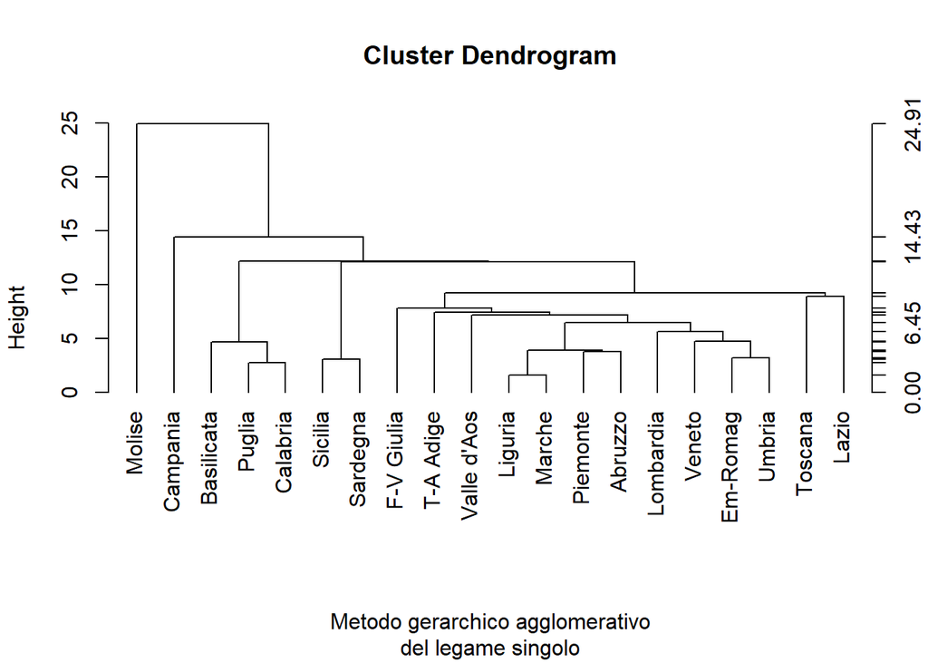

```r
plot(hls, hang = -1, xlab = "Metodo gerarchico agglomerativo",
     sub="del legame singolo")
axis(side = 4, at= round(c(0, hls$height), 2))
```

La funzione *axis(side = 4, at= round(c(0, hls$height), 2))* ci permette di costruire l’asse delle altezze alla destra del grafico, arrotondando alla seconda cifra decimale.

Per scegliere una buona partizione del dendrogramma, consideriamo un grafico detto **screenplot**, sul quale asse delle ordinate vengono posti i numeri di gruppi ottenibili con il meotodo gerarchico e sull’asse ascisse vengono le distanze a cui avvengono le successive aggregazioni fra gruppi. Al fine di fornire misure quantitative degli incrementi riscontrati tra le distanze a cui avvengono le successive agglomerazioni, consideriamo la seguente quantità:
$$\delta_k = d_{k-1} - d_k \qquad (k=2,...,n)$$
dove $d_k$ rappresenta il livello di distanza a cui è stata effettuata l’agglomerazione in k gruppi e n è il numero iniziale di individui. Quando $\delta_k$ risulta sufficientemente elevato allora i gruppi sono dissimili fra loro ed è possibile tagliare il dendrogramma all’altezza corrispondente alla partizione in k gruppi. È possibile utilizzare lo screenplot solo per i metodi gerarchici del legame singolo, medio e completo in quanto con i metodi del centroide e della mediana, le successive agglomerazioni potrebbero verificarsi ad un livello di distanza minore o uguale rispetto alle precedenti. Questa procedura però non fornisce sempre la suddivisione in cluster più adeguata, infatti è sempre preferibile utilizzare le misure di non omogeneità statistiche.

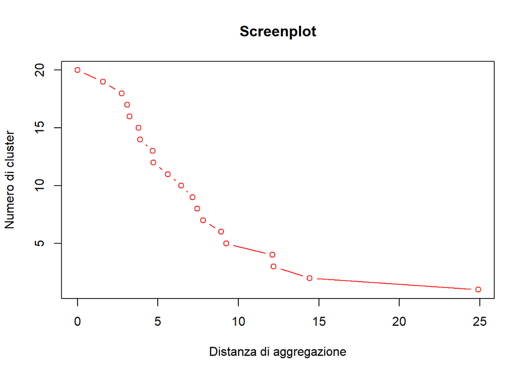

```r
plot(c(0, hls$height), seq(20, 1), type = "b", main = "Screenplot",
     xlab = "Distanza di aggregazione", ylab = "Numero di cluster", col = "red")
```

```r
hls$height
```

```
##  [1]  1.581139  2.740894  3.080844  3.229938  3.789670  3.892300  4.683332
##  [8]  4.715930  5.625913  6.447240  7.160000  7.450503  7.814243  8.924887
## [15]  9.234479 12.124871 12.189848 14.428444 24.909719
```

In questo caso il max lo abbiamo fra:

$$\delta_2 = h_1 - h_2 = 24.909719 - 14.428444 = 10.48127$$
Quindi il valore di k per il quale $\delta_k$ è massimo si ha con $k=2$. Applichiamo la suddivisione al dendrogramma utilizzando la funzione *rect.hclust()*:

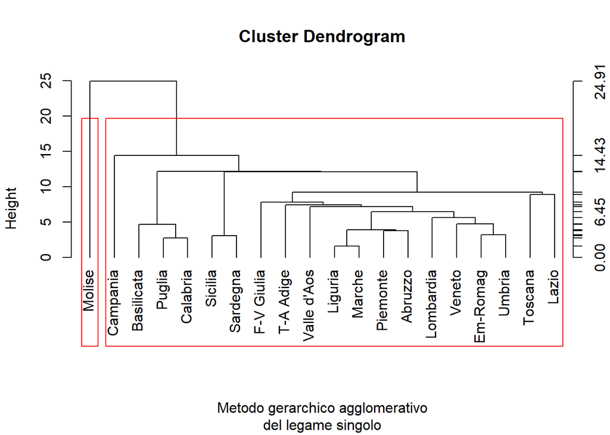

```r
plot(hls, hang = -1, xlab = "Metodo gerarchico agglomerativo",
     sub="del legame singolo")
axis(side = 4, at= round(c(0, hls$height), 2))
rect.hclust(hls, k=2)
```

Per ottenere la suddivisione in cluster oltre che graficamente, è possibile utilizzare la funzione *cutree()*.

```r
cutree(hls, k=2)
```

```
##    Piemonte Valle d'Aos     Liguria   Lombardia   T-A Adige      Veneto
##           1           1           1           1           1           1
##  F-V Giulia    Em-Romag     Toscana      Umbria      Marche       Lazio
##           1           1           1           1           1           1
##     Abruzzo      Molise    Campania      Puglia  Basilicata    Calabria
##           1           2           1           1           1           1
##     Sicilia    Sardegna
##           1           1
```

Calcoliamo adesso la misura di non omogeneità statistica totale

```r
n <- nrow(tabella)
trHI <- (n-1) * sum(apply(tabella, 2, var))
trHI
```

```
## [1] 7067.801
```

```r
d <- dist(tabella, method="euclidean", diag = TRUE, upper=TRUE)
d2<-d^2
tree <- hclust(d2, method = "single")
taglio <-cutree(tree, k=2, h=NULL)
num <- table(taglio)
tagliolist <- list(taglio)

agvar <- aggregate(tabella, tagliolist, var)[,-1]

trH1<-(num[[1]]-1) * sum(agvar[1,])
if(is.na(trH1))
  trH1 <- 0

trH2<-(num[[2]]-1) * sum(agvar[2,])
if(is.na(trH2))
  trH2 <- 0

trS <- trH1 + trH2

trB <- trHI-trH1-trH2
trB
```

```
## [1] 2681.522
```

```r
trB/trHI
```

```
## [1] 0.3793997
```

Con la suddivisione in due cluster otteniamo una misura di non omogeneità tra cluster pari a 2681.522. Questa suddivisione ricordiamo, ci è stata suggerita anche dallo scatterplot. Il rapporto fra trB/trHI è pari a 0.3793997 un valore decisamente basso che ci porta all’aumentare il numero di cluster.

```r
d <- dist(tabella, method="euclidean", diag = TRUE, upper=TRUE)
d2<-d^2
tree <- hclust(d2, method = "single")
taglio <-cutree(tree, k=3, h=NULL)
num <- table(taglio)
tagliolist <- list(taglio)

agvar <- aggregate(tabella, tagliolist, var)[,-1]

trH1<-(num[[1]]-1) * sum(agvar[1,])
if(is.na(trH1))
  trH1 <- 0

trH2<-(num[[2]]-1) * sum(agvar[2,])
if(is.na(trH2))
  trH2 <- 0

trH3<-(num[[3]]-1) * sum(agvar[3,])
if(is.na(trH3))
  trH3 <- 0

trS <- trH1 + trH2 + trH3

trB <- trHI-trH1-trH2-trH3
trB/trHI
```

```
## [1] 0.4232395
```

```r
d <- dist(tabella, method="euclidean", diag = TRUE, upper=TRUE)
d2<-d^2
tree <- hclust(d2, method = "single")
taglio <-cutree(tree, k=4, h=NULL)
num <- table(taglio)
tagliolist <- list(taglio)

agvar <- aggregate(tabella, tagliolist, var)[,-1]

trH1<-(num[[1]]-1) * sum(agvar[1,])
if(is.na(trH1))
  trH1 <- 0

trH2<-(num[[2]]-1) * sum(agvar[2,])
if(is.na(trH2))
  trH2 <- 0

trH3<-(num[[3]]-1) * sum(agvar[3,])
if(is.na(trH3))
  trH3 <- 0

trH4<-(num[[4]]-1) * sum(agvar[4,])
if(is.na(trH4))
  trH4 <- 0

trS <- trH1 + trH2 + trH3 + trH4

trB <- trHI-trH1-trH2-trH3-trH4
trB/trHI
```

```
## [1] 0.7699938
```

La suddivisione in quattro cluster, suggeritaci durante l’analisi con i metodi non gerarchici, ci ha portato al risultato migliore fra le tre suddivisioni con un rapporto fra trB/trHI pari a 0.7699938, che ricade nel range di valori accettabili.

### Metodo del legame completo

In questo metodo la distanza tra i gruppi $G_1$ e $G_2$ è definita come la massima tra tutte le $n_1n_2$ distanze che si possono calcolare tra ogni individuo di $G_1$ e ogni individuo di $G_2$. A livello 0, viene considerato inizialmente un insieme di *n* cluster, uno per ogni individuo. Nel passo successivo, si cerca il coefficiente di distanza minima all’interno della matrice delle distanze D e si raggruppano nello stesso cluster i due individui ad esso associati. A livello 1 si modifica la matrice delle distanze valutando le distanze dal cluster appena creato con gli altri mediante la seguente relazione:

$$d_{(ij),k} = max(d_{ik}, d_{jk})$$
Ad ogni passo successivo vengono ripetute le stesse azioni, funo ad ottenere un unico cluster formato da tutti gli individui.

```r
d <- dist(tabella, method = "euclidean",
          diag = TRUE, upper = FALSE)
hlc <- hclust(d, method = "complete")
str(hlc)
```

```
## List of 7
##  $ merge      : int [1:19, 1:2] -3 -16 -19 -8 -1 1 -4 -17 -2 -9 ...
##  $ height     : num [1:19] 1.58 2.74 3.08 3.23 3.79 ...
##  $ order      : int [1:20] 15 9 12 8 10 4 6 2 5 7 ...
##  $ labels     : chr [1:20] "Piemonte" "Valle d'Aos" "Liguria" "Lombardia" ...
##  $ method     : chr "complete"
##  $ call       : language hclust(d = d, method = "complete")
##  $ dist.method: chr "euclidean"
##  - attr(*, "class")= chr "hclust"
```

Procediamo adesso alla stampa del dendrogramma:

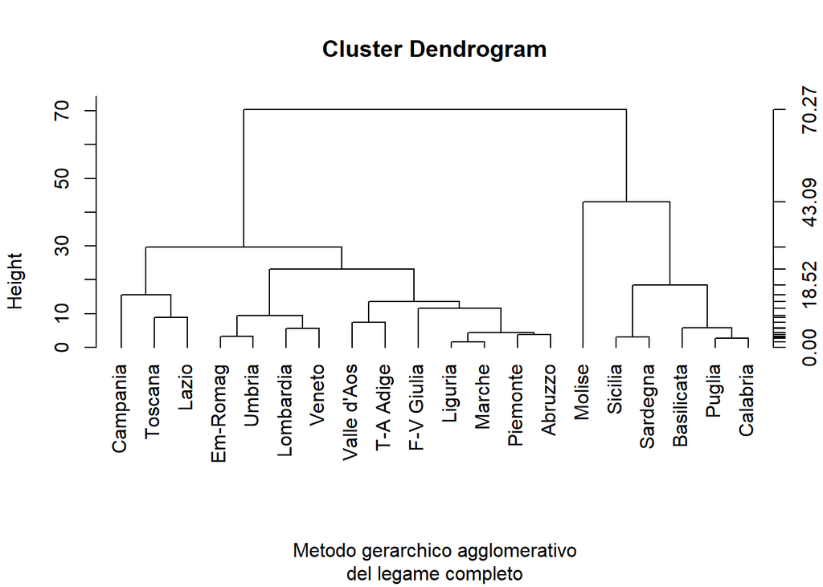

```r
plot(hlc, hang = -1, xlab = "Metodo gerarchico agglomerativo",
     sub="del legame completo")
axis(side = 4, at= round(c(0, hlc$height), 2))
```

Come fatto in precedenza, procediamo alla stampa dello screenplot:

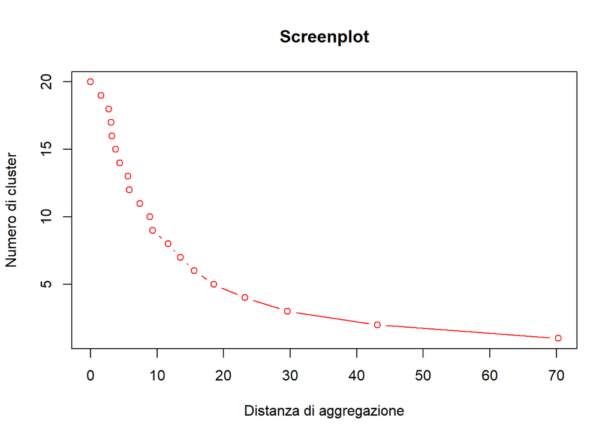

```r
plot(c(0, hlc$height), seq(20, 1), type = "b",
     main = "Screenplot", xlab = "Distanza di aggregazione",
     ylab = "Numero di cluster", col = "red")
```

```r
hlc$height
```

```
##  [1]  1.581139  2.740894  3.080844  3.229938  3.789670  4.366646  5.625913
##  [8]  5.838502  7.450503  8.924887  9.335331 11.648966 13.542688 15.594281
## [15] 18.522605 23.213791 29.604001 43.088240 70.274764
```

Anche in questo caso il max lo abbiamo fra:

$$\delta_2 = h_1 - h_2 = 70.274764 - 43.088240 = 27.186524$$
Quindi il valore di k per il quale $\delta_k$ è massimo si ha con $k=2$. Applichiamo la suddivisione al dendrogramma utilizzando la funzione *rect.hclust()*:

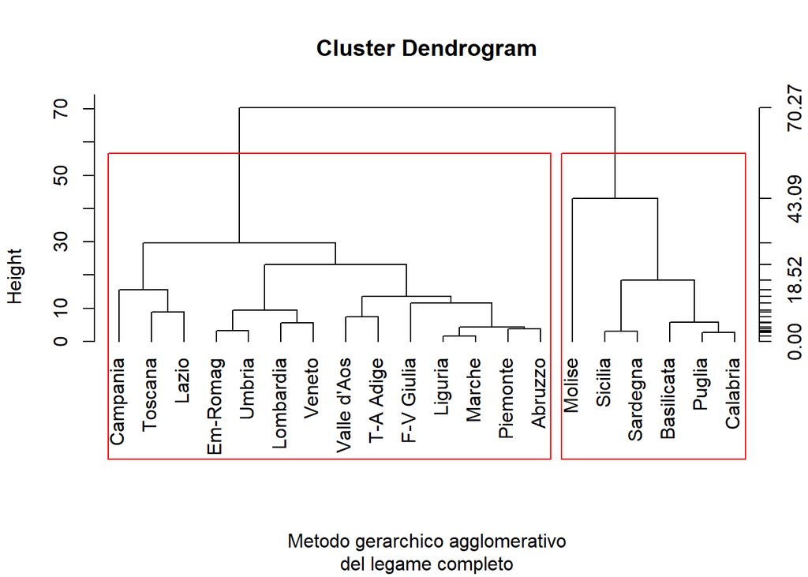

```r
plot(hlc, hang = -1, xlab = "Metodo gerarchico agglomerativo",
     sub="del legame completo")
axis(side = 4, at= round(c(0, hlc$height), 2))
rect.hclust(hlc, k=2)
```

Per ottenere la suddivisione in cluster oltre che graficamente, è possibile utilizzare la funzione *cutree()*.

```r
cutree(hlc, k=2)
```

```
##    Piemonte Valle d'Aos     Liguria   Lombardia   T-A Adige      Veneto
##           1           1           1           1           1           1
##  F-V Giulia    Em-Romag     Toscana      Umbria      Marche       Lazio
##           1           1           1           1           1           1
##     Abruzzo      Molise    Campania      Puglia  Basilicata    Calabria
##           1           2           1           2           2           2
##     Sicilia    Sardegna
##           2           2
```

Procediamo adesso all’analisi utilizzando le misure di non omogeneità statistiche, in quanto, anche in precedenza sono risultate essere più precise rispetto allo screenplot. Faremo l’analisi per la suddivisione in 2,3 e 4 cluster.

Siccome la misura di non omogeneità statistica totale è uguale a quella calcolata in precedenza evitiamo di ricalcolarla.

Procediamo al calcolo delle misure di omogeneità statistiche per le varie suddivisioni:

```r
d <- dist(tabella, method="euclidean",
          diag = TRUE, upper=TRUE)
d2<-d^2
tree <- hclust(d2, method = "complete")
taglio <-cutree(tree, k=2, h=NULL)
num <- table(taglio)
tagliolist <- list(taglio)

agvar <- aggregate(tabella, tagliolist, var)[,-1]

trH1<-(num[[1]]-1) * sum(agvar[1,])
if(is.na(trH1))
  trH1 <- 0

trH2<-(num[[2]]-1) * sum(agvar[2,])
if(is.na(trH2))
  trH2 <- 0

trS <- trH1 + trH2

trB <- trHI-trH1-trH2
trB/trHI
```

```
## [1] 0.6405491
```

Con la suddivisione in due cluster, suggeritaci dallo scatterplot, il rapporto tra $\frac{trB}{trT}$ non è risultato essere abbastanza alto.

```r
d <- dist(tabella, method="euclidean",
          diag = TRUE, upper=TRUE)
d2<-d^2
tree <- hclust(d2, method = "complete")
taglio <-cutree(tree, k=3, h=NULL)
num <- table(taglio)
tagliolist <- list(taglio)

agvar <- aggregate(tabella, tagliolist, var)[,-1]

trH1<-(num[[1]]-1) * sum(agvar[1,])
if(is.na(trH1))
  trH1 <- 0

trH2<-(num[[2]]-1) * sum(agvar[2,])
if(is.na(trH2))
  trH2 <- 0

trH3<-(num[[3]]-1) * sum(agvar[3,])
if(is.na(trH3))
  trH3 <- 0

trS <- trH1 + trH2 + trH3

trB <- trHI-trH1-trH2-trH3
trB/trHI
```

```
## [1] 0.7718826
```

Con la suddivisione in tre cluster invece il rapporto tra $\frac{trB}{trT}$ ha raggiunto un risultato di sufficienza ed è possibile tenerlo in considerazione.

```r
d <- dist(tabella, method="euclidean",
          diag = TRUE, upper=TRUE)
d2<-d^2
tree <- hclust(d2, method = "complete")
taglio <-cutree(tree, k=4, h=NULL)
num <- table(taglio)
tagliolist <- list(taglio)

agvar <- aggregate(tabella, tagliolist, var)[,-1]

trH1<-(num[[1]]-1) * sum(agvar[1,])
if(is.na(trH1))
  trH1 <- 0

trH2<-(num[[2]]-1) * sum(agvar[2,])
if(is.na(trH2))
  trH2 <- 0

trH3<-(num[[3]]-1) * sum(agvar[3,])
if(is.na(trH3))
  trH3 <- 0

trH4<-(num[[4]]-1) * sum(agvar[4,])
if(is.na(trH4))
  trH4 <- 0

trS <- trH1 + trH2 + trH3 + trH4

trB <- trHI-trH1-trH2-trH3-trH4
trB/trHI
```

```
## [1] 0.8529709
```

Con quest’ultima suddivisione, suggeritaci dal metodo k-means fatto in precedenza, il rapporto fra $\frac{trB}{trT}$ raggiunge il risultato più alto fra tutti quelli visti con i metodi gerarchici e risulta essere un ottimo risultato dato il numero di cluster scelti. Da notare che il valore è pressochè identico a quello trovato con il metodo k-means.

La relativa suddivisione in cluster è la seguente:

```r
cutree(hlc, k=4, h=NULL)
```

```
##    Piemonte Valle d'Aos     Liguria   Lombardia   T-A Adige      Veneto
##           1           1           1           1           1           1
##  F-V Giulia    Em-Romag     Toscana      Umbria      Marche       Lazio
##           1           1           2           1           1           2
##     Abruzzo      Molise    Campania      Puglia  Basilicata    Calabria
##           1           3           2           4           4           4
##     Sicilia    Sardegna
##           4           4
```

### Metodo del legame medio

In questo metodo la distanza tra i gruppi $G_1$ e $G_2$ è definita come la media aritmetica delle distanze fra tutte le coppie che compongono gli insiemi. All’inizio del metodo, a livello 0 abbiato tanti cluster quanti sono gli individui. Successivamente controlliamo la matrice delle distanze D e raggruppiamo nello stesso cluster gli individui associati alla distanza minima. A livello 1 di modifica la matrice delle distanze valutando le distanze del cluster appena creato e tutti gli altri rimanenti, mediante la seguente relazione:

$$d_{(i,j),k} = \frac{1}{2}(d_{i,k}+d_{j,k}) \qquad (k=1,2,...,n;k\neq i,j)$$
Viene quindi costruita una nuova matrice delle distanze. Ad ogni passo successivo, dopo aver individuato i due cluster da raggruppare, la distanza fra il nuovo cluster $G_{uv}$ e un altro cluster $G_z$ è definita nella seguente maniera:

$$d_{(uv),z} = \frac{N_u}{N_u+N_v}d_{uz} + \frac{N_v}{N_u+N_v}d_{vz}$$

dove $N_u$, $N_v$ e $N_z$ sono rispettivamente il numero di individui del cluster $G_u$, $G_v$ e $G_z$. La procedura si ripete fino a quando non si ottiene un unico cluster con tutti gli individui.

```r
d <- dist(tabella, method = "euclidean",
          diag = TRUE, upper = FALSE)
hlm <- hclust(d, method = "average")
str(hlm)
```

```
## List of 7
##  $ merge      : int [1:19, 1:2] -3 -16 -19 -8 -1 1 -17 -6 -2 -4 ...
##  $ height     : num [1:19] 1.58 2.74 3.08 3.23 3.79 ...
##  $ order      : int [1:20] 14 19 20 17 16 18 15 9 12 3 ...
##  $ labels     : chr [1:20] "Piemonte" "Valle d'Aos" "Liguria" "Lombardia" ...
##  $ method     : chr "average"
##  $ call       : language hclust(d = d, method = "average")
##  $ dist.method: chr "euclidean"
##  - attr(*, "class")= chr "hclust"
```

Procediamo adesso alla stampa del dendrogramma:

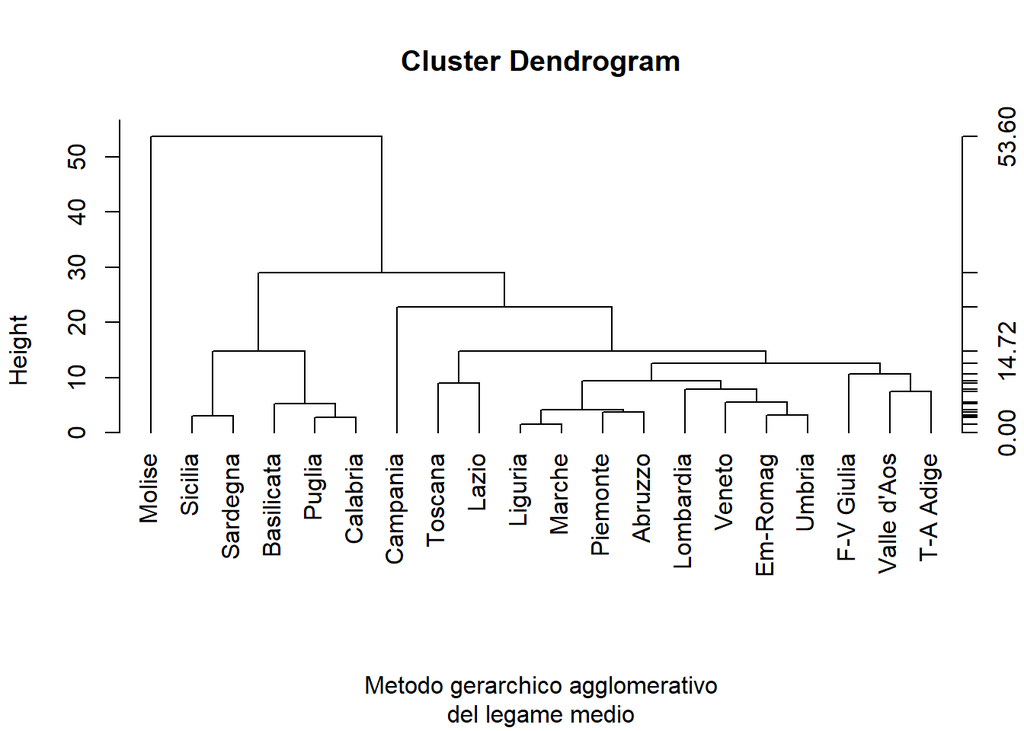

```r
plot(hlm, hang = -1, xlab = "Metodo gerarchico agglomerativo",
     sub="del legame medio")
axis(side = 4, at= round(c(0, hlm$height), 2))
```

Come fatto in precedenza, procediamo alla stampa dello screenplot:

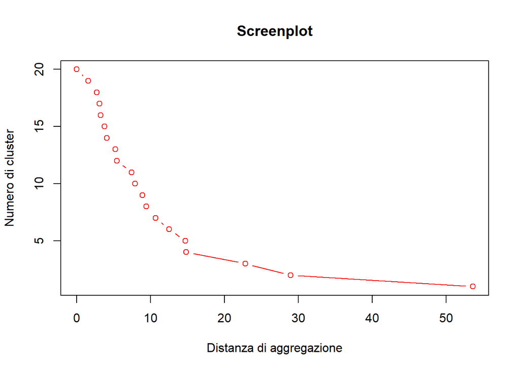

```r
plot(c(0, hlm$height), seq(20, 1), type = "b",
     main = "Screenplot", xlab = "Distanza di aggregazione",
     ylab = "Numero di cluster", col = "red")
```

```r
hlm$height
```

```
##  [1]  1.581139  2.740894  3.080844  3.229938  3.789670  4.104984  5.260917
##  [8]  5.464511  7.450503  7.920432  8.924887  9.445813 10.678466 12.520514
## [15] 14.724801 14.813469 22.808357 28.947554 53.603492
```

Anche in questo caso il max lo abbiamo fra:

$$\delta_2 = h_1 - h_2 = 53.603492 - 28.947554 = 24.65594$$

Quindi il valore di k per il quale $\delta_k$ è massimo si ha con $k=2$. Applichiamo la suddivisione al dendrogramma utilizzando la funzione *rect.hclust()*:

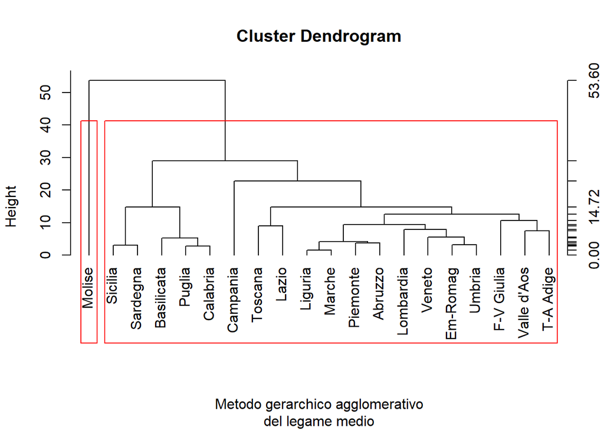

```r
plot(hlm, hang = -1, xlab = "Metodo gerarchico agglomerativo",
     sub="del legame medio")
axis(side = 4, at= round(c(0, hlm$height), 2))
rect.hclust(hlm, k=2)
```

Per ottenere la suddivisione in cluster oltre che graficamente, è possibile utilizzare la funzione *cutree()*.

```r
cutree(hlm, k=2)
```

```
##    Piemonte Valle d'Aos     Liguria   Lombardia   T-A Adige      Veneto
##           1           1           1           1           1           1
##  F-V Giulia    Em-Romag     Toscana      Umbria      Marche       Lazio
##           1           1           1           1           1           1
##     Abruzzo      Molise    Campania      Puglia  Basilicata    Calabria
##           1           2           1           1           1           1
##     Sicilia    Sardegna
##           1           1
```

Procediamo adesso all’analisi utilizzando le misure di non omogeneità statistiche, in quanto, anche in precedenza sono risultate essere più precise rispetto allo screenplot. Faremo l’analisi per la suddivisione in 2,3 e 4 cluster.

Siccome la misura di non omogeneità statistica totale è uguale a quella calcolata in precedenza evitiamo di ricalcolarla.

Procediamo al calcolo delle misure di omogeneità statistiche per le varie suddivisioni:

```r
d <- dist(tabella, method="euclidean",
          diag = TRUE, upper=TRUE)
d2<-d^2
tree <- hclust(d2, method = "average")
taglio <-cutree(tree, k=2, h=NULL)
num <- table(taglio)
tagliolist <- list(taglio)

agvar <- aggregate(tabella, tagliolist, var)[,-1]

trH1<-(num[[1]]-1) * sum(agvar[1,])
if(is.na(trH1))
  trH1 <- 0

trH2<-(num[[2]]-1) * sum(agvar[2,])
if(is.na(trH2))
  trH2 <- 0

trS <- trH1 + trH2

trB <- trHI-trH1-trH2
trB/trHI
```

```
## [1] 0.3793997
```

Con la suddivisione in due cluster, suggeritaci dallo scatterplot, il rapporto tra $\frac{trB}{trT}$ è risultato essere estremamente basso.

```r
d <- dist(tabella, method="euclidean",
          diag = TRUE, upper=TRUE)
d2<-d^2
tree <- hclust(d2, method = "average")
taglio <-cutree(tree, k=3, h=NULL)
num <- table(taglio)
tagliolist <- list(taglio)

agvar <- aggregate(tabella, tagliolist, var)[,-1]

trH1<-(num[[1]]-1) * sum(agvar[1,])
if(is.na(trH1))
  trH1 <- 0

trH2<-(num[[2]]-1) * sum(agvar[2,])
if(is.na(trH2))
  trH2 <- 0

trH3<-(num[[3]]-1) * sum(agvar[3,])
if(is.na(trH3))
  trH3 <- 0

trS <- trH1 + trH2 + trH3

trB <- trHI-trH1-trH2-trH3
trB/trHI
```

```
## [1] 0.7718826
```

Con la suddivisione in tre cluster invece il rapporto tra $\frac{trB}{trT}$ ha raggiunto un risultato di sufficienza ed è possibile tenerlo in considerazione.

```r
d <- dist(tabella, method="euclidean",
          diag = TRUE, upper=TRUE)
d2<-d^2
tree <- hclust(d2, method = "average")
taglio <-cutree(tree, k=4, h=NULL)
num <- table(taglio)
tagliolist <- list(taglio)

agvar <- aggregate(tabella, tagliolist, var)[,-1]

trH1<-(num[[1]]-1) * sum(agvar[1,])
if(is.na(trH1))
  trH1 <- 0

trH2<-(num[[2]]-1) * sum(agvar[2,])
if(is.na(trH2))
  trH2 <- 0

trH3<-(num[[3]]-1) * sum(agvar[3,])
if(is.na(trH3))
  trH3 <- 0

trH4<-(num[[4]]-1) * sum(agvar[4,])
if(is.na(trH4))
  trH4 <- 0

trS <- trH1 + trH2 + trH3 + trH4

trB <- trHI-trH1-trH2-trH3-trH4
trB/trHI
```

```
## [1] 0.8529709
```

Con quest’ultima suddivisione, suggeritaci dal metodo k-means fatto in precedenza, il rapporto fra $\frac{trB}{trT}$ raggiunge il risultato più alto fra i precedenti ed è in linea con quello ottenuto con il metodo del legame completo e risulta essere un ottimo risultato dato il numero di cluster scelti. Da notare che il valore è pressochè identico a quello trovato con il metodo k-means.

La relativa suddivisione in cluster è la seguente:

```r
cutree(hlm, k=4, h=NULL)
```

```
##    Piemonte Valle d'Aos     Liguria   Lombardia   T-A Adige      Veneto
##           1           1           1           1           1           1
##  F-V Giulia    Em-Romag     Toscana      Umbria      Marche       Lazio
##           1           1           1           1           1           1
##     Abruzzo      Molise    Campania      Puglia  Basilicata    Calabria
##           1           2           3           4           4           4
##     Sicilia    Sardegna
##           4           4
```

### Metodo del centroide

In questo metodo la distanza tra il gruppo $G_1$ e il gruppo $G_2$ è definita come la distanza tra i centroidi, ovvero le medie campionarie calcolate sugli individui dei gruppi. A differenza dei metodi precedenti qui viene considerata la matrice contenente i quadrati delle singole distanze euclidee.

```r
d <- dist(tabella, method = "euclidean",
          diag = TRUE, upper = FALSE)
d2 <- d^2
hlcentroid <- hclust(d2, method = "centroid")
str(hlcentroid)
```

```
## List of 7
##  $ merge      : int [1:19, 1:2] -3 -16 -19 -8 -1 1 -17 -6 6 -2 ...
##  $ height     : num [1:19] 2.5 7.51 9.49 10.43 14.36 ...
##  $ order      : int [1:20] 14 17 16 18 7 19 20 15 3 11 ...
##  $ labels     : chr [1:20] "Piemonte" "Valle d'Aos" "Liguria" "Lombardia" ...
##  $ method     : chr "centroid"
##  $ call       : language hclust(d = d2, method = "centroid")
##  $ dist.method: chr "euclidean"
##  - attr(*, "class")= chr "hclust"
```

Procediamo adesso alla stampa del dendrogramma:

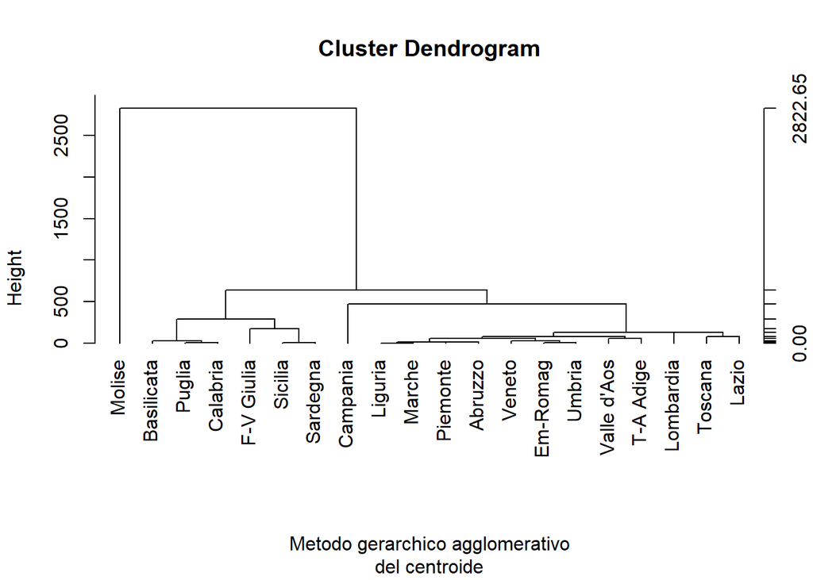

```r
plot(hlcentroid, hang = -1, xlab = "Metodo gerarchico agglomerativo",
     sub="del centroide")
axis(side = 4, at= round(c(0, hlcentroid$height), 2))
```

Procediamo adesso all’analisi utilizzando le misure di non omogeneità statistiche. Faremo l’analisi per la suddivisione in 2,3 e 4 cluster.

Siccome la misura di non omogeneità statistica totale è uguale a quella calcolata in precedenza evitiamo di ricalcolarla.

Procediamo al calcolo delle misure di omogeneità statistiche per le varie suddivisioni:

```r
d <- dist(tabella, method="euclidean",
          diag = TRUE, upper=TRUE)
d2<-d^2
tree <- hclust(d2, method = "centroid")
taglio <-cutree(tree, k=2, h=NULL)
num <- table(taglio)
tagliolist <- list(taglio)

agvar <- aggregate(tabella, tagliolist, var)[,-1]

trH1<-(num[[1]]-1) * sum(agvar[1,])
if(is.na(trH1))
  trH1 <- 0

trH2<-(num[[2]]-1) * sum(agvar[2,])
if(is.na(trH2))
  trH2 <- 0

trS <- trH1 + trH2

trB <- trHI-trH1-trH2
trB/trHI
```

```
## [1] 0.3793997
```

Con la suddivisione in due cluster, suggeritaci dallo scatterplot, il rapporto tra $\frac{trB}{trT}$ è risultato essere estremamente basso.

```r
d <- dist(tabella, method="euclidean",
          diag = TRUE, upper=TRUE)
d2<-d^2
tree <- hclust(d2, method = "centroid")
taglio <-cutree(tree, k=3, h=NULL)
num <- table(taglio)
tagliolist <- list(taglio)

agvar <- aggregate(tabella, tagliolist, var)[,-1]

trH1<-(num[[1]]-1) * sum(agvar[1,])
if(is.na(trH1))
  trH1 <- 0

trH2<-(num[[2]]-1) * sum(agvar[2,])
if(is.na(trH2))
  trH2 <- 0

trH3<-(num[[3]]-1) * sum(agvar[3,])
if(is.na(trH3))
  trH3 <- 0

trS <- trH1 + trH2 + trH3

trB <- trHI-trH1-trH2-trH3
trB/trHI
```

```
## [1] 0.7525784
```

Con la suddivisione in tre cluster invece il rapporto tra $\frac{trB}{trT}$ ha raggiunto un risultato di sufficienza ed è possibile tenerlo in considerazione.

```r
d <- dist(tabella, method="euclidean",
          diag = TRUE, upper=TRUE)
d2<-d^2
tree <- hclust(d2, method = "centroid")
taglio <-cutree(tree, k=4, h=NULL)
num <- table(taglio)
tagliolist <- list(taglio)

agvar <- aggregate(tabella, tagliolist, var)[,-1]

trH1<-(num[[1]]-1) * sum(agvar[1,])
if(is.na(trH1))
  trH1 <- 0

trH2<-(num[[2]]-1) * sum(agvar[2,])
if(is.na(trH2))
  trH2 <- 0

trH3<-(num[[3]]-1) * sum(agvar[3,])
if(is.na(trH3))
  trH3 <- 0

trH4<-(num[[4]]-1) * sum(agvar[4,])
if(is.na(trH4))
  trH4 <- 0

trS <- trH1 + trH2 + trH3 + trH4

trB <- trHI-trH1-trH2-trH3-trH4
trB/trHI
```

```
## [1] 0.8146854
```

Con quest’ultima suddivisione, suggeritaci dal metodo k-means fatto in precedenza, il rapporto fra $\frac{trB}{trT}$ raggiunge il risultato più alto fra i precedenti ed è poco inferiore a quello ottenuto con i due metodi precedenti e risulta essere un ottimo risultato dato il numero di cluster scelti.

La relativa suddivisione in cluster è la seguente:

```r
cutree(hlm, k=4, h=NULL)
```

[output not shown]

### Metodo della mediana

Questo metodo è simile a quello del centroide e differisce per il fatto che la procedura è indipendente dalla numerosità dei cluster. Infatti, quando due gruppi si aggregano il nuovo centroide è calcolato come la semisomma dei due centroidi precedenti. Anche il metodo della mediana, come quello del legame singolo può dare vita alla formazione di una catena fra gli individui.

```r
d <- dist(tabella, method = "euclidean",
          diag = TRUE, upper = FALSE)
d2 <- d^2
hlmedian <- hclust(d2, method = "median")
str(hlmedian)
```

```
## List of 7
##  $ merge      : int [1:19, 1:2] -3 -16 -19 -8 -1 1 -17 -6 -4 -2 ...
##  $ height     : num [1:19] 2.5 7.51 9.49 10.43 14.36 ...
##  $ order      : int [1:20] 14 19 20 17 16 18 15 7 3 11 ...
##  $ labels     : chr [1:20] "Piemonte" "Valle d'Aos" "Liguria" "Lombardia" ...
##  $ method     : chr "median"
##  $ call       : language hclust(d = d2, method = "median")
##  $ dist.method: chr "euclidean"
##  - attr(*, "class")= chr "hclust"
```

Procediamo adesso alla stampa del dendrogramma:

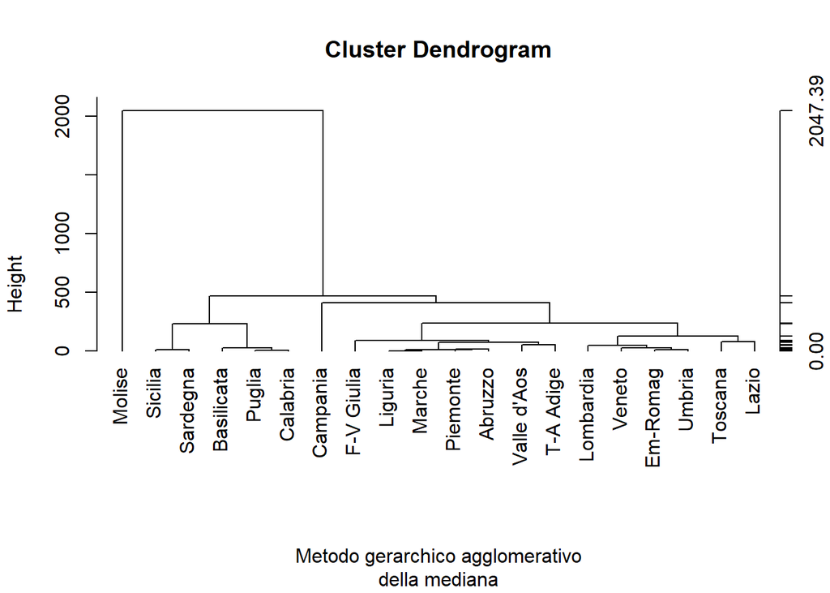

```r
plot(hlmedian, hang = -1, xlab = "Metodo gerarchico agglomerativo",
     sub="della mediana")
axis(side = 4, at= round(c(0, hlmedian$height), 2))
```

Procediamo adesso all’analisi utilizzando le misure di non omogeneità statistiche. Faremo l’analisi per la suddivisione in 2,3 e 4 cluster.

Siccome la misura di non omogeneità statistica totale è uguale a quella calcolata in precedenza evitiamo di ricalcolarla.

Procediamo al calcolo delle misure di omogeneità statistiche per le varie suddivisioni:

```r
d <- dist(tabella, method="euclidean",
          diag = TRUE, upper=TRUE)
d2<-d^2
tree <- hclust(d2, method = "median")
taglio <-cutree(tree, k=2, h=NULL)
num <- table(taglio)
tagliolist <- list(taglio)

agvar <- aggregate(tabella, tagliolist, var)[,-1]

trH1<-(num[[1]]-1) * sum(agvar[1,])
if(is.na(trH1))
  trH1 <- 0

trH2<-(num[[2]]-1) * sum(agvar[2,])
if(is.na(trH2))
  trH2 <- 0

trS <- trH1 + trH2

trB <- trHI-trH1-trH2
trB/trHI
```

```
## [1] 0.3793997
```

Con la suddivisione in due cluster, suggeritaci dallo scatterplot, il rapporto tra $\frac{trB}{trT}$ è risultato essere estremamente basso.

```r
d <- dist(tabella, method="euclidean",
          diag = TRUE, upper=TRUE)
d2<-d^2
tree <- hclust(d2, method = "median")
taglio <-cutree(tree, k=3, h=NULL)
num <- table(taglio)
tagliolist <- list(taglio)

agvar <- aggregate(tabella, tagliolist, var)[,-1]

trH1<-(num[[1]]-1) * sum(agvar[1,])
if(is.na(trH1))
  trH1 <- 0

trH2<-(num[[2]]-1) * sum(agvar[2,])
if(is.na(trH2))
  trH2 <- 0

trH3<-(num[[3]]-1) * sum(agvar[3,])
if(is.na(trH3))
  trH3 <- 0

trS <- trH1 + trH2 + trH3

trB <- trHI-trH1-trH2-trH3
trB/trHI
```

```
## [1] 0.7718826
```

Con la suddivisione in tre cluster invece il rapporto tra $\frac{trB}{trT}$ ha raggiunto un risultato di sufficienza ed è possibile tenerlo in considerazione.

```r
d <- dist(tabella, method="euclidean",
          diag = TRUE, upper=TRUE)
d2<-d^2
tree <- hclust(d2, method = "median")
taglio <-cutree(tree, k=4, h=NULL)
num <- table(taglio)
tagliolist <- list(taglio)

agvar <- aggregate(tabella, tagliolist, var)[,-1]

trH1<-(num[[1]]-1) * sum(agvar[1,])
if(is.na(trH1))
  trH1 <- 0

trH2<-(num[[2]]-1) * sum(agvar[2,])
if(is.na(trH2))
  trH2 <- 0

trH3<-(num[[3]]-1) * sum(agvar[3,])
if(is.na(trH3))
  trH3 <- 0

trH4<-(num[[4]]-1) * sum(agvar[4,])
if(is.na(trH4))
  trH4 <- 0

trS <- trH1 + trH2 + trH3 + trH4

trB <- trHI-trH1-trH2-trH3-trH4
trB/trHI
```

```
## [1] 0.833741
```

La relativa suddivisione in cluster è la seguente:

```r
cutree(hlm, k=4, h=NULL)
```

```
##    Piemonte Valle d'Aos     Liguria   Lombardia   T-A Adige      Veneto
##           1           1           1           1           1           1
##  F-V Giulia    Em-Romag     Toscana      Umbria      Marche       Lazio
##           1           1           1           1           1           1
##     Abruzzo      Molise    Campania      Puglia  Basilicata    Calabria
##           1           2           3           4           4           4
##     Sicilia    Sardegna
##           4           4
```

$C_1$ *= {Emilia Romagna, Umbria, Valle d’Aosta, Veneto, Lombardia, Trentino-alto Adige, Friuli-venezia Giulia, Liguria, Marche, Piemonte, Abruzzo, Lazio, Toscana}* $C_2$ *= {Molise}* $C_3$ *= {Campania}* $C_4$ *= {Sicilia, Sardegna, Basilicata, Puglia, Calabria}*